# IODS Open Data Science course project

Leena Huiku

2018

output: html

# Exercise 1. About the project

## Description of the course

The Open data science course is a comprehensive introduction to open science, open data, and open research tools.After completing this course, the student will be able to visualize and analyze data set with statistical methods. The tools which are used on the course are freely available, open software tools. The principle of to reproduce research data set is a basic idea on this course. Huge amount of data produced by research institutes, statistical organisations and public data providers are available to extract and utilise for purposes of different kind. The course offers tools for gain new skills and understanding in order to better understand the phenomena behind the data. (https://github.com/Leenapaivikki/IODS-project)

# Exercise 2. Analysis of the Learning Data

# Description of data

The data of the analysis derives from the survey “Learning Approaches and Students’ Achievements” in an Introductory Statistics Course in Finland in 2014. The target of the study is to measure the relationship between the students’ learning approaches and their achievements.

There are 183 observations and 60 variables. Most of the questions are learning related questions, the answers are given on Likert scale from 1 to 5. Some background variables (age, attitude to statistics, points) are included as well. The learning approaches variables - deep learning, surface learning and strategic learning - are created by combing questions that can be thought to measure the same dimension. The combination variables are averaged.

# Load of data

```r
learning2014v2 <- as.data.frame(read.table('learning2014.csv', sep="\t", header=TRUE))
```

# Explore the structure of the dataframe

```r
str(learning2014v2)
```

```
## 'data.frame':    166 obs. of  7 variables:
##  $ gender  : Factor w/ 2 levels "F","M": 1 2 1 2 2 1 2 1 2 1 ...
##  $ age     : int  53 55 49 53 49 38 50 37 37 42 ...
##  $ attitude: int  37 31 25 35 37 38 35 29 38 21 ...
##  $ points  : int  25 12 24 10 22 21 21 31 24 26 ...
##  $ deep    : num  3.58 2.92 3.5 3.5 3.67 ...
##  $ stra    : num  3.38 2.75 3.62 3.12 3.62 ...
##  $ surf    : num  2.58 3.17 2.25 2.25 2.83 ...
```

# Explore the dimension of the dataframe

```r
dim(learning2014v2)
```

```
## [1] 166   7
```

# Show a graphical overview of the data and show summaries of the variables in the data.

If there are a handul of variables, it is possible to visulize The relationships between the variables in a single plot. A scatter plot matrix can be drawn by using function ggpairs and coloured by the gender variable.

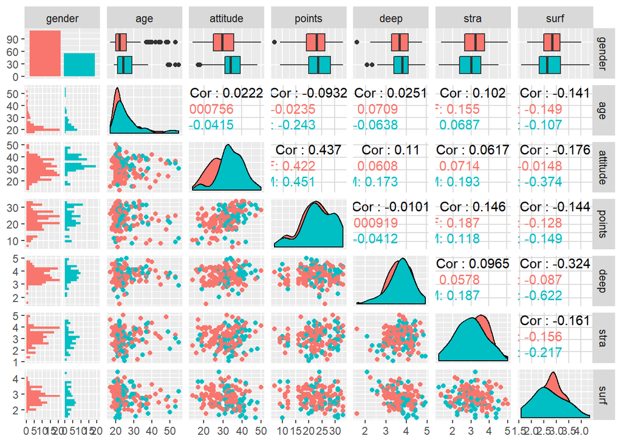

```r
p <- ggpairs(learning2014v2, mapping = aes(col=gender), lower = list(combo = wrap("facethist", bins = 20)))
p
```

# A summary of each of the variables

```r
summary(learning2014v2)
```

```
##  gender       age           attitude         points           deep
##  F:110   Min.   :17.00   Min.   :14.00   Min.   : 7.00   Min.   :1.583
##  M: 56   1st Qu.:21.00   1st Qu.:26.00   1st Qu.:19.00   1st Qu.:3.333
##          Median :22.00   Median :32.00   Median :23.00   Median :3.667
##          Mean   :25.51   Mean   :31.43   Mean   :22.72   Mean   :3.680
##          3rd Qu.:27.00   3rd Qu.:37.00   3rd Qu.:27.75   3rd Qu.:4.083
##          Max.   :55.00   Max.   :50.00   Max.   :33.00   Max.   :4.917
##       stra            surf
##  Min.   :1.250   Min.   :1.583
##  1st Qu.:2.625   1st Qu.:2.417
##  Median :3.188   Median :2.833
##  Mean   :3.121   Mean   :2.787
##  3rd Qu.:3.625   3rd Qu.:3.167
##  Max.   :5.000   Max.   :4.333
```

# Description and interpretation of the outputs

The graphical overview and the summary of the data showcase the large range of variables. The distribution of the variables is quite wide. The target of this analysis is to clarify the relationship of the student’s learning approaches and the results achieved. The correlations between variables are rather weak in all cases. The attitude variable is exception, it correlates strongly with the points variable. The age distribution shows that most students are at their twenties as could be assumed. The gender distribution is skewed, significantly more female students attended the course than male. The distributions of attitude, deep, stra and surf variables follow rather close to normal distribution. The points distribution is skewed, the distribution demonstrates that the student achieved good results.

# Regression model fitting

A linear regression model can be fit using lm function The explanatory variables are attitude, deep and stra.

```r
learning2014v2_model <- lm(points ~ attitude + deep + stra, data = learning2014v2)
```

```r
summary(learning2014v2_model)
```

```
##
## Call:
## lm(formula = points ~ attitude + deep + stra, data = learning2014v2)
##
## Residuals:
##      Min       1Q   Median       3Q      Max
## -17.5239  -3.4276   0.5474   3.8220  11.5112
##
## Coefficients:
##             Estimate Std. Error t value Pr(>|t|)
## (Intercept) 11.39145    3.40775   3.343  0.00103 **
## attitude     0.35254    0.05683   6.203 4.44e-09 ***
## deep        -0.74920    0.75066  -0.998  0.31974
## stra         0.96208    0.53668   1.793  0.07489 .
## ---
## Signif. codes:  0 '***' 0.001 '**' 0.01 '*' 0.05 '.' 0.1 ' ' 1
##
## Residual standard error: 5.289 on 162 degrees of freedom
## Multiple R-squared:  0.2097, Adjusted R-squared:  0.195
## F-statistic: 14.33 on 3 and 162 DF,  p-value: 2.521e-08
```

The dependent variable is points and the explanatory variables are attitude, deep and stra.

The model is found by minimizing the sum of squared residuals. First there is a five point summary of residuals of the model. The coefficients give the estimates of the parameters of the model. Intercept relates to parameters of output variable.

The estimation describes the effect of an explanatory variable on the output variable. P value of the statistical test is very low in case attitude so we can conclude that there is statistical relationship between attitude and points. The P test values of deep and stra are much higher and indicates that the variables don’t have strong relationship with output variable. The deep variable has lowest correlation with points, so it can be excluded from the further analysis.

The explanatory variables in the next fitted test are attitude and stra.

```r
learning2014v2_model <- lm(points ~ attitude + stra, data = learning2014v2)
```

```r
summary(learning2014v2_model)
```

```
##
## Call:
## lm(formula = points ~ attitude + stra, data = learning2014v2)
##
## Residuals:
##      Min       1Q   Median       3Q      Max
## -17.6436  -3.3113   0.5575   3.7928  10.9295
##
## Coefficients:
##             Estimate Std. Error t value Pr(>|t|)
## (Intercept)  8.97290    2.39591   3.745  0.00025 ***
## attitude     0.34658    0.05652   6.132 6.31e-09 ***
## stra         0.91365    0.53447   1.709  0.08927 .
## ---
## Signif. codes:  0 '***' 0.001 '**' 0.01 '*' 0.05 '.' 0.1 ' ' 1
##
## Residual standard error: 5.289 on 163 degrees of freedom
## Multiple R-squared:  0.2048, Adjusted R-squared:  0.1951
## F-statistic: 20.99 on 2 and 163 DF,  p-value: 7.734e-09
```

# Final analysis

The fitted model was created by removing one explanatory variable, the deep variable, which have weak correlation with the output variable and the other variables. Based on the summary of the fitted model it can be concluded that the deep variable doesn’t have much impact on the model. The statistical significance of the model is rather good. The p-value is low. The model as a whole is not good, because the Multiple R-squarded value is only 0.20 which implies that only 20% of the relationship between the output value points and the explanatory variables can be explain with this model. Thus 80% on the relationship remains unexplained.

## Diagnostic plots and assumptions and their validity of the model

There are three assumptions of linear regression models: the errors are normally distributed, they are not correlated and have constant variance. QQ-plot of the residuals provides a method to explore the assumption that the errors are normally distributed. The constant variance assumption implies that the size of the errors should not depend on the explanatory variables and it can be explored with a simple scatter plot of residuals versus model predictions. Any pattern in the scatter plot implies a problem with the assumptions.

The next diagnostic plots are produced: Residuals vs Fitted values, Normal QQ-plot, Residuals vs Leverage.

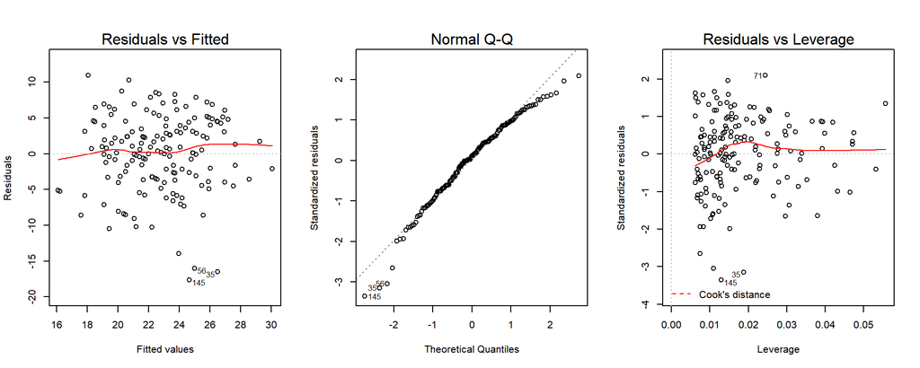

```r
par(mfrow = c(1,3))
# Draw diagnostic plots using the plot() function. Choose the plots 1, 2 and 5
plot(learning2014v2_model, which = c(1,2,5))
```

# Interpretation of the plots:

The Residuals vs Fitted plot doesn’t show any kind of pattern and the values are randomly distributed. Based on that, it can be concluded that the errors are not correlated with the explanatory variables and their size is not dependent on the explanatory variables.

The Normal Q-Q-plot Residuals diagnostic plot showcases that the model fits to the theoretical model rather well. The better the points are within the line, the better the model fits to the normality assumption.

Leverage of observations measures, how much impact a single observation has on the model. Residuals vs Leverage plot helps to identify which observations have an unusually high impact. The single outliner can have high impact on the model. In this case there is no outliner in the plot and the result of the diagnostic is regular leverage.

# Exercise 3. Analysis of the student performance including alcohol consumption

# Introduction

The data of this analysis is from the Portugese survey on student performance in secondary education (high school). The database was built from two sources: school reports and questionnaires, the latter used to complement the previous information. The data was collected during the years 2005-2006. The performance was scrutinized in two distinct subjects: Mathematics and Portuguese language.

The datasets were modelled by P. Cortez and A. Silva, described in the paper “Using Data Mining to Predict Secondary School Student Performance” (2008) http://www3.dsi.uminho.pt/pcortez/student.pdf

## Description of the data

To read the data in.

```r
alc <- as.data.frame(read.table('data/alc.csv',  sep="\t", header=TRUE))
```

All variables of the data can be displayed by using glimpse function.

```r
glimpse(alc)
```

```
## Observations: 382
## Variables: 35
## $ school     <fct> GP, GP, GP, GP, GP, GP, GP, GP, GP, GP, GP, GP, GP,...
## $ sex        <fct> F, F, F, F, F, M, M, F, M, M, F, F, M, M, M, F, F, ...
## $ age        <int> 18, 17, 15, 15, 16, 16, 16, 17, 15, 15, 15, 15, 15,...
## $ address    <fct> U, U, U, U, U, U, U, U, U, U, U, U, U, U, U, U, U, ...
## $ famsize    <fct> GT3, GT3, LE3, GT3, GT3, LE3, LE3, GT3, LE3, GT3, G...
## $ Pstatus    <fct> A, T, T, T, T, T, T, A, A, T, T, T, T, T, A, T, T, ...
## $ Medu       <int> 4, 1, 1, 4, 3, 4, 2, 4, 3, 3, 4, 2, 4, 4, 2, 4, 4, ...
## $ Fedu       <int> 4, 1, 1, 2, 3, 3, 2, 4, 2, 4, 4, 1, 4, 3, 2, 4, 4, ...
## $ Mjob       <fct> at_home, at_home, at_home, health, other, services,...
## $ Fjob       <fct> teacher, other, other, services, other, other, othe...
## $ reason     <fct> course, course, other, home, home, reputation, home...
## $ nursery    <fct> yes, no, yes, yes, yes, yes, yes, yes, yes, yes, ye...
## $ internet   <fct> no, yes, yes, yes, no, yes, yes, no, yes, yes, yes,...
```

[output cut: 22 more lines]

The dataset consists of 35 variables and 382 observations. The variables are of both numerical and character type. There are also binary variables.

The data variables include student grades, demographic, social and school related features. Special attention is paid on the alcoholic consumption and its possible impact on student performance. There are two alcohol consumption variables - daily and weekly use - which are combined and averaged to variable alc_use. The target variable is binary (low/high) variable consumption of alcohol.

## Four interesting variables to explain the alcohol consumption

The purpose of the analysis is to study the relationships between high/low alcohol consumption and some of the other variables in the data. After some experiments, I have chosen four explanatory variables that might be indicators of alcohol consumption.

1. Weekly study time could indicate to alcohol consumption - variable studytime.
2. Students who go out with friends could use more alcohol - variable goout.
3. Number of school absences, which could be an indicator of alcohol consumption - variable absenses.
4. Results in final grade, students with poor results might drink more alcohol - variable G3.

A summary and four plots of the chosen variables are showcased below.

```r
summary(alc[c('studytime', 'goout', 'absences', 'G3')])
```

```
##    studytime         goout          absences          G3
##  Min.   :1.000   Min.   :1.000   Min.   : 0.0   Min.   : 0.00
##  1st Qu.:1.000   1st Qu.:2.000   1st Qu.: 1.0   1st Qu.:10.00
##  Median :2.000   Median :3.000   Median : 3.0   Median :12.00
##  Mean   :2.037   Mean   :3.113   Mean   : 4.5   Mean   :11.46
##  3rd Qu.:2.000   3rd Qu.:4.000   3rd Qu.: 6.0   3rd Qu.:14.00
##  Max.   :4.000   Max.   :5.000   Max.   :45.0   Max.   :18.00
```

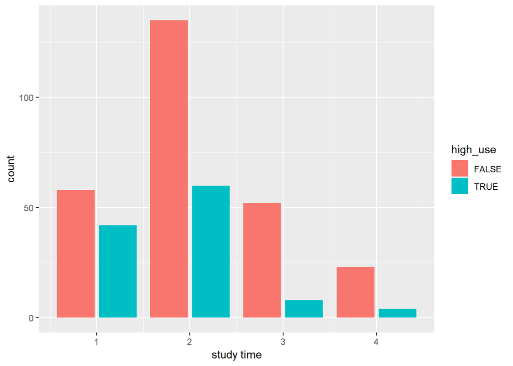

```r
v1 <- ggplot(data = alc, aes(studytime))
v1 + geom_bar(aes(fill = high_use), stat="count", position = "dodge2") + xlab('study time')
```

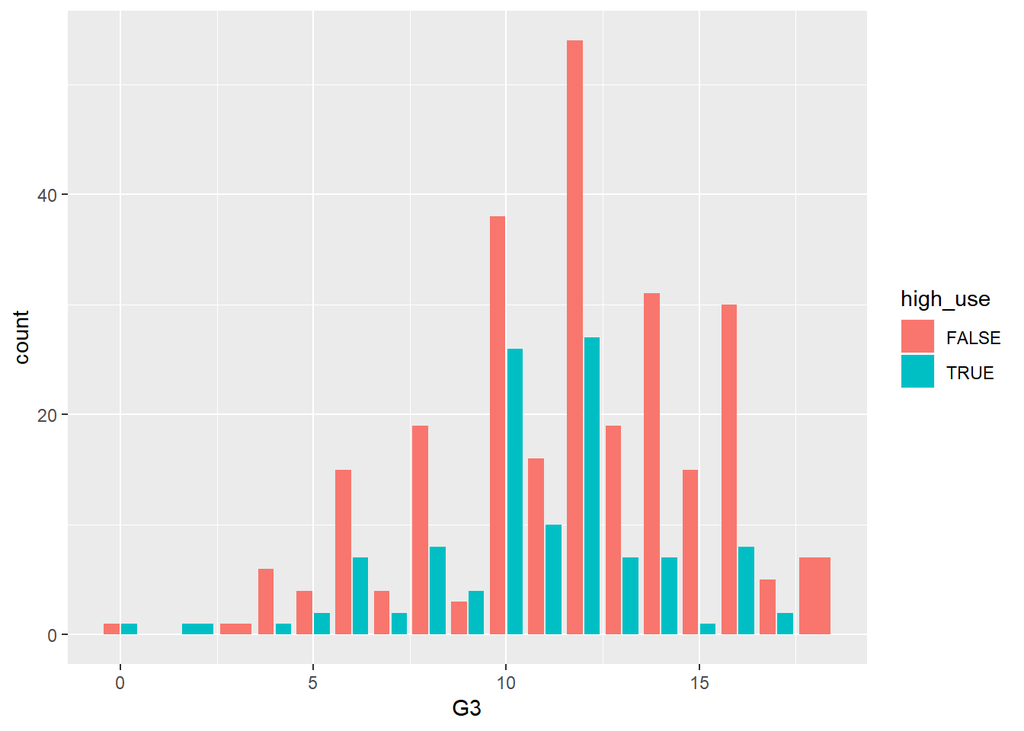

```r
v2 <- ggplot(data = alc, aes(G3))
v2 + geom_bar(aes(fill = high_use), stat="count", position = "dodge2") + xlab('G3')
```

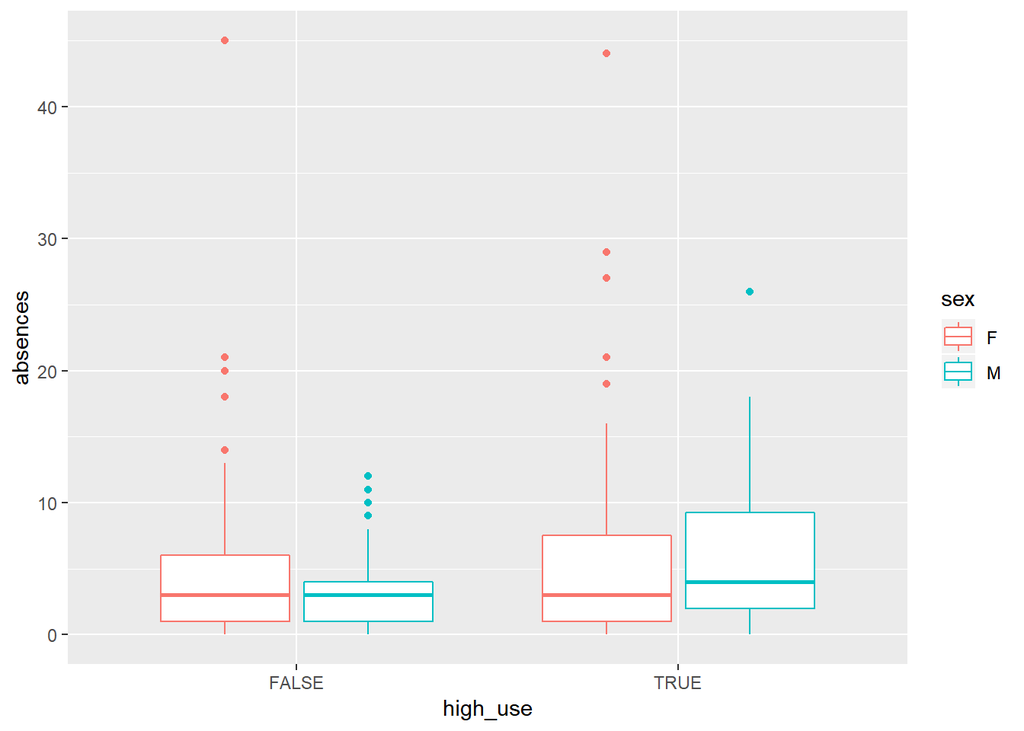

```r
v3 <- ggplot(data = alc, aes(x = high_use, y=absences, col = sex))
v3 + geom_boxplot() + xlab("high_use")
```

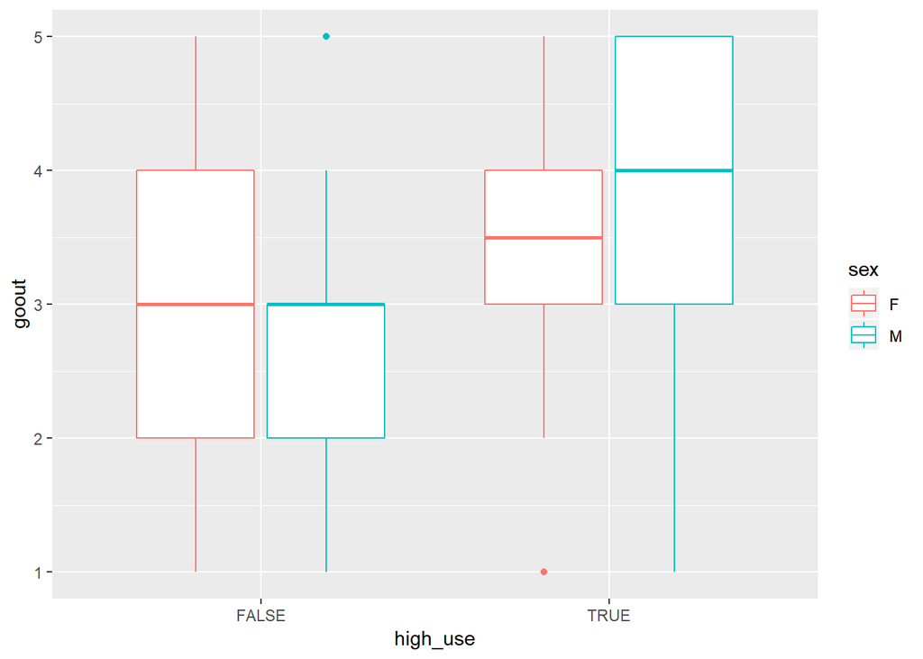

```r
v4 <- ggplot(data = alc, aes(x = high_use, y=goout, col = sex))
v4 + geom_boxplot() + xlab("high_use")
```

# Logistic regression analysis

Based on the summary and graphics above, the four assumptioms stated earlier seemed to be eligible at least to some extent. The next step is to use logistic regression to statistically explore the relationship between my chosen explanatory variables and the binary high/low alcohol consumption variable as the target variable.

A summary of the fitted model is presented and interpreted.

```r
m <- glm(high_use ~  + studytime + goout + absences + G3, data = alc, family = "binomial")
summary(m)
```

```
##
## Call:
## glm(formula = high_use ~ +studytime + goout + absences + G3,
##     family = "binomial", data = alc)
##
## Deviance Residuals:
##     Min       1Q   Median       3Q      Max
## -1.8717  -0.7686  -0.5171   0.8345   2.4941
##
## Coefficients:
##             Estimate Std. Error z value Pr(>|z|)
## (Intercept) -2.15991    0.69106  -3.125  0.00178 **
## studytime   -0.54223    0.16834  -3.221  0.00128 **
## goout        0.71610    0.11855   6.040 1.54e-09 ***
## absences     0.06912    0.02205   3.135  0.00172 **
## G3          -0.02831    0.03925  -0.721  0.47074
## ---
## Signif. codes:  0 '***' 0.001 '**' 0.01 '*' 0.05 '.' 0.1 ' ' 1
##
## (Dispersion parameter for binomial family taken to be 1)
##
##     Null deviance: 465.68  on 381  degrees of freedom
## Residual deviance: 389.62  on 377  degrees of freedom
## AIC: 399.62
##
## Number of Fisher Scoring iterations: 4
```

The summary of the fitted model showcases that there is relatively strong relationship between alcohol consumption and other variables except G3 final grade results. The study time, going out with friends and the number of school absences explain the alcohol consumption rather well and the results are statistically significant.

The next step is to present and interpret the coefficients of the model as odds ratios.

```r
OR <- exp(coef(m))
OR
```

```
## (Intercept)   studytime       goout    absences          G3
##   0.1153350   0.5814504   2.0464293   1.0715608   0.9720874
```

Odds ratio can be used to quantify the relationship between variables. The exponents of the coefficients can be interpreted as odds ratios between a unit change (vs no change) in the corresponding explanatory variable.

Confidence intervals are provided for odds ratios.

```r
CI <-exp(confint(m))
cbind(OR, CI)
```

```
##                    OR      2.5 %    97.5 %
## (Intercept) 0.1153350 0.02867633 0.4342130
## studytime   0.5814504 0.41353969 0.8016563
## goout       2.0464293 1.63144106 2.5994233
## absences    1.0715608 1.02739900 1.1214957
## G3          0.9720874 0.90012478 1.0503315
```

The results above showcase that the confidence intervals of the odds rations imply the same conclusion that the final frade G3 hypothesis was wrong. The new fitted model is created and calculated by removing variable G3. A new summary and recalcutions of the odds rations (OR) and the confidental intervals (CI) are carried out.

```r
m <- glm(high_use ~ studytime + goout + absences, data = alc, family = "binomial")
summary(m)
```

```
##
## Call:
## glm(formula = high_use ~ studytime + goout + absences, family = "binomial",
##     data = alc)
##
## Deviance Residuals:
##     Min       1Q   Median       3Q      Max
## -1.8457  -0.7733  -0.5178   0.8432   2.5036
##
## Coefficients:
##             Estimate Std. Error z value Pr(>|z|)
## (Intercept) -2.48582    0.52982  -4.692 2.71e-06 ***
## studytime   -0.56048    0.16672  -3.362 0.000774 ***
## goout        0.72735    0.11786   6.171 6.78e-10 ***
## absences     0.07011    0.02204   3.181 0.001470 **
## ---
## Signif. codes:  0 '***' 0.001 '**' 0.01 '*' 0.05 '.' 0.1 ' ' 1
##
## (Dispersion parameter for binomial family taken to be 1)
##
##     Null deviance: 465.68  on 381  degrees of freedom
## Residual deviance: 390.14  on 378  degrees of freedom
## AIC: 398.14
##
## Number of Fisher Scoring iterations: 4
```

```r
cbind(exp(coef(m)), exp(confint(m)))
```

```
##                             2.5 %    97.5 %
## (Intercept) 0.08325721 0.02864231 0.2297441
## studytime   0.57093348 0.40733791 0.7846264
## goout       2.06958310 1.65203749 2.6250666
## absences    1.07262851 1.02840235 1.1225709
```

The statistics above showcase that the recalculated new model contains explanatory variables that are statistically significant. The confidence intervals show that the model can be used for predictions.

# Prediction of the model

According to the logistic regression model above, it is possible to explore the predictive power of the model.

The next steps are required:

```r
# Predict the probability of high_use
probabilities <- predict(m, type = "response")

# Add the predicted probabilities to 'alc'
alc <- mutate(alc, probability = probabilities)

# Use the probabilities to make a prediction of high_use
alc <- mutate(alc, prediction = probability > 0.5)

# Tabulate the target variable versus the predictions
tbl <- table(high_use = alc$high_use, prediction = alc$prediction)
addmargins(tbl)
```

```
##         prediction
## high_use FALSE TRUE Sum
##    FALSE   246   22 268
##    TRUE     66   48 114
##    Sum     312   70 382
```

```r
round(addmargins(prop.table(tbl)), 2)
```

```
##         prediction
## high_use FALSE TRUE  Sum
##    FALSE  0.64 0.06 0.70
##    TRUE   0.17 0.13 0.30
##    Sum    0.82 0.18 1.00
```

The statistics above show that the model predicts less occurences of high use than the survey data contain. The percentage of students who use a lot of alcohol is 30% based on the survey data. The model predicts that the percentage is 18%. This can be shown by graphics:

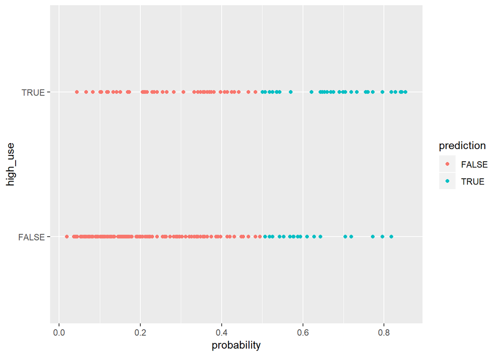

```r
g = ggplot(alc, aes(x = probability, y = high_use, col=prediction))
g+geom_point()
```

## Computation the total proportion of inaccurately classified individuals (= the training error)

The logistic regression aim to (approximately) minimize the incorrectly classified observations. Since we know how to make predictions with our model, we can also compute the average number of incorrect predictions. First define a loss function (mean prediction error).

```r
loss_func = function(class, prob) {
  n_wrong = abs(class - prob) > 0.5
  mean(n_wrong)
}
# Call loss_func to compute the average number of wrong predictions in the (training) data
loss_func(class = alc$high_use, prob = alc$probability)
```

```
## [1] 0.2303665
```

The training error is 23%, which implies that the accuracy of the model is a little over 76%. The accuracy is not very high, but as we have seen, my choice of the explanatory variables didn’t succeed perfectly as well. All explanatory variables were not statistically significant so by the guessing strategy the results were not better.

# Cross-validation (bonus task)

Cross-validation is a method of testing a predictive model on unseen data. In cross-validation, the value of a penalty (loss) function (mean prediction error) is computed on data not used for finding the model. Low value = good. Cross-validation gives a good estimate of the actual predictive power of the model.

I perform 10-fold cross-validation on my model.

```r
# 10-fold cross-validation
cv <- cv.glm(data = alc, cost = loss_func, glmfit = m, K = 10)

# Print the average number of wrong predictions in the cross validation
cv$delta[1]
```

```
## [1] 0.2356021
```

The average number of wrong predictions of my model = 0.2356021, which is better than in the IODS course’s DataCamp exercises = 0.2591623.

To improve the model it is possible to add explanatory variables into the model and recalculate the cross-validation. Based on the DataCamp material there are two variables that could be added to my model: failures and sex. I will add the sex variable as an explanatory variable, because it correlates strongly with the target variable according to DataCamp calculations.

```r
m_2 <- glm(high_use ~ studytime + goout + absences + sex, data = alc, family = "binomial")
# Summary of the model
summary(m_2)
```

```
##
## Call:
## glm(formula = high_use ~ studytime + goout + absences + sex,
##     family = "binomial", data = alc)
##
## Deviance Residuals:
##     Min       1Q   Median       3Q      Max
## -1.9103  -0.7892  -0.5021   0.7574   2.6021
##
## Coefficients:
##             Estimate Std. Error z value Pr(>|z|)
## (Intercept) -3.20483    0.59429  -5.393 6.94e-08 ***
## studytime   -0.42116    0.17058  -2.469 0.013551 *
## goout        0.72677    0.11994   6.059 1.37e-09 ***
## absences     0.07811    0.02244   3.481 0.000499 ***
## sexM         0.78173    0.26555   2.944 0.003242 **
## ---
## Signif. codes:  0 '***' 0.001 '**' 0.01 '*' 0.05 '.' 0.1 ' ' 1
##
## (Dispersion parameter for binomial family taken to be 1)
##
##     Null deviance: 465.68  on 381  degrees of freedom
## Residual deviance: 381.31  on 377  degrees of freedom
## AIC: 391.31
##
## Number of Fisher Scoring iterations: 4
```

```r
#Calculations of the odds of ratios and the confidence interval
cbind(exp(coef(m_2)), exp(confint(m_2)))
```

```
##                             2.5 %    97.5 %
## (Intercept) 0.04056573 0.01222314 0.1263579
## studytime   0.65628388 0.46510383 0.9099505
## goout       2.06838526 1.64470314 2.6349716
## absences    1.08123884 1.03577383 1.1324143
## sexM        2.18525582 1.30370562 3.7010763
```

```r
# Prediction of the probability
probabilities_2 <- predict(m_2, type = "response")
# Probabilities to alc
alc <- mutate(alc, probability_2 = probabilities_2)
# Calculate a logical high use value based on probabilities.
alc <- mutate(alc, prediction_2 = probability_2 > 0.5)
# Recalculation of cross-validation and print the average number of wrong predictions.
cv_2 <- cv.glm(data = alc, cost = loss_func, glmfit = m_2, K = 10)
cv_2$delta[1]
```

```
## [1] 0.2225131
```

# Exercise 4. Clustering and classification of Boston data

## Introduction

The data of this exercise 4 derives from dataset Housing Values in Suburbs of Boston from the 1970s, which is available on the R package MASS. The data contains 506 observations and 14 variables. More information: https://stat.ethz.ch/R-manual/R-devel/library/MASS/html/Boston.html

This data frame contains the following variables:  
-crim: per capita crime rate by town.  
-zn: proportion of residential land zoned for lots over 25,000 sq.ft.  
-indus: proportion of non-retail business acres per town.  
-chas: Charles River dummy variable (= 1 if tract bounds river; 0 otherwise).  
-nox: nitrogen oxides concentration (parts per 10 million).  
-rm: average number of rooms per dwelling.  
-age: proportion of owner-occupied units built prior to 1940.  
-dis: weighted mean of distances to five Boston employment centres.  
-rad:index of accessibility to radial highways.  
-tax: full-value property-tax rate per $10,000.  
-ptratio: pupil-teacher ratio by town.  
-black: 1000(Bk - 0.63)^2 where Bk is the proportion of blacks by town.  
-lstat: lower status of the population (percent).  
-medv: median value of owner-occupied homes in $1000s.

The dataset has been introduced in two publications  
-Harrison, D. and Rubinfeld, D.L. (1978) Hedonic prices and the demand for clean air. J. Environ. Economics and Management 5, 81-102.  
-Belsley D.A., Kuh, E. and Welsch, R.E. (1980) Regression Diagnostics. Identifying Influential Data and Sources of Collinearity. New York: Wiley.

# Loading the data

The data is available in R package MASS and can be loaded by following step

```r
# Data input, to load the Boston dataset from MASS
data("Boston")
```

# Graphical overview of the data and summaries of the variables

Let’s have a look on the structure and dimension of the dataset loaded above.

```r
# Exploration of the data
str(Boston)
```

```
## 'data.frame':    506 obs. of  14 variables:
##  $ crim   : num  0.00632 0.02731 0.02729 0.03237 0.06905 ...
##  $ zn     : num  18 0 0 0 0 0 12.5 12.5 12.5 12.5 ...
##  $ indus  : num  2.31 7.07 7.07 2.18 2.18 2.18 7.87 7.87 7.87 7.87 ...
##  $ chas   : int  0 0 0 0 0 0 0 0 0 0 ...
##  $ nox    : num  0.538 0.469 0.469 0.458 0.458 0.458 0.524 0.524 0.524 0.524 ...
##  $ rm     : num  6.58 6.42 7.18 7 7.15 ...
##  $ age    : num  65.2 78.9 61.1 45.8 54.2 58.7 66.6 96.1 100 85.9 ...
##  $ dis    : num  4.09 4.97 4.97 6.06 6.06 ...
##  $ rad    : int  1 2 2 3 3 3 5 5 5 5 ...
##  $ tax    : num  296 242 242 222 222 222 311 311 311 311 ...
##  $ ptratio: num  15.3 17.8 17.8 18.7 18.7 18.7 15.2 15.2 15.2 15.2 ...
##  $ black  : num  397 397 393 395 397 ...
##  $ lstat  : num  4.98 9.14 4.03 2.94 5.33 ...
##  $ medv   : num  24 21.6 34.7 33.4 36.2 28.7 22.9 27.1 16.5 18.9 ...
```

```r
summary(Boston)
```

```
##       crim                zn             indus            chas
##  Min.   : 0.00632   Min.   :  0.00   Min.   : 0.46   Min.   :0.00000
##  1st Qu.: 0.08204   1st Qu.:  0.00   1st Qu.: 5.19   1st Qu.:0.00000
##  Median : 0.25651   Median :  0.00   Median : 9.69   Median :0.00000
##  Mean   : 3.61352   Mean   : 11.36   Mean   :11.14   Mean   :0.06917
##  3rd Qu.: 3.67708   3rd Qu.: 12.50   3rd Qu.:18.10   3rd Qu.:0.00000
##  Max.   :88.97620   Max.   :100.00   Max.   :27.74   Max.   :1.00000
##       nox               rm             age              dis
##  Min.   :0.3850   Min.   :3.561   Min.   :  2.90   Min.   : 1.130
##  1st Qu.:0.4490   1st Qu.:5.886   1st Qu.: 45.02   1st Qu.: 2.100
##  Median :0.5380   Median :6.208   Median : 77.50   Median : 3.207
##  Mean   :0.5547   Mean   :6.285   Mean   : 68.57   Mean   : 3.795
##  3rd Qu.:0.6240   3rd Qu.:6.623   3rd Qu.: 94.08   3rd Qu.: 5.188
##  Max.   :0.8710   Max.   :8.780   Max.   :100.00   Max.   :12.127
##       rad              tax           ptratio          black
##  Min.   : 1.000   Min.   :187.0   Min.   :12.60   Min.   :  0.32
##  1st Qu.: 4.000   1st Qu.:279.0   1st Qu.:17.40   1st Qu.:375.38
##  Median : 5.000   Median :330.0   Median :19.05   Median :391.44
##  Mean   : 9.549   Mean   :408.2   Mean   :18.46   Mean   :356.67
##  3rd Qu.:24.000   3rd Qu.:666.0   3rd Qu.:20.20   3rd Qu.:396.23
##  Max.   :24.000   Max.   :711.0   Max.   :22.00   Max.   :396.90
##      lstat            medv
##  Min.   : 1.73   Min.   : 5.00
##  1st Qu.: 6.95   1st Qu.:17.02
##  Median :11.36   Median :21.20
##  Mean   :12.65   Mean   :22.53
##  3rd Qu.:16.95   3rd Qu.:25.00
##  Max.   :37.97   Max.   :50.00
```

Exploration of the data graphigally

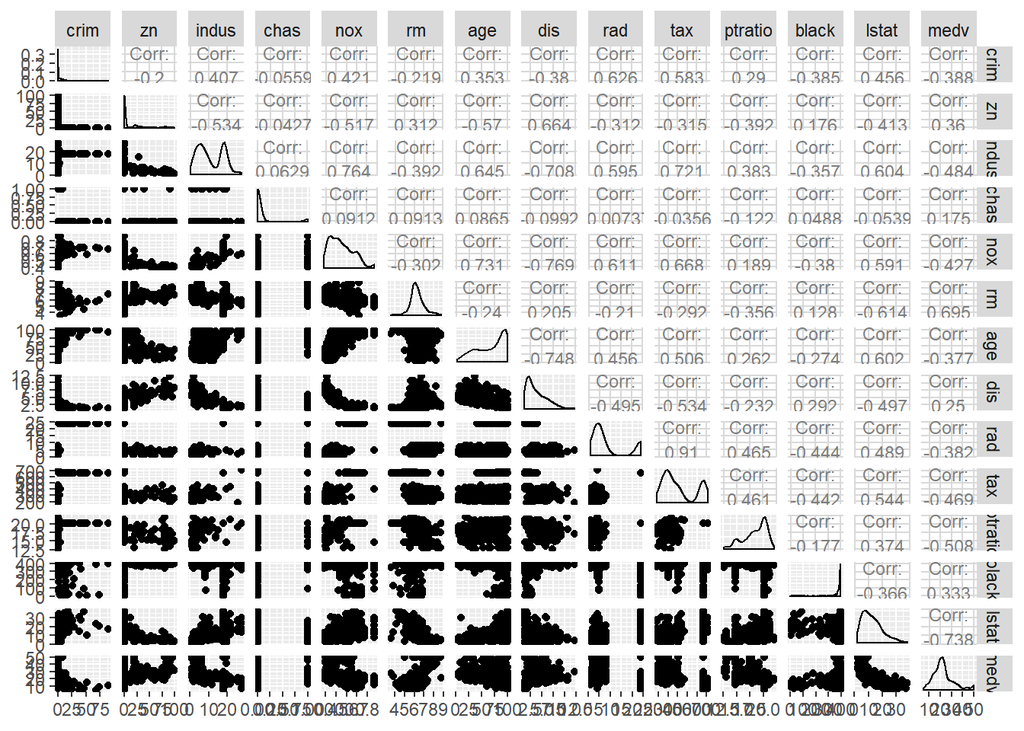

```r
p <- ggpairs(Boston, mapping = aes(), lower = list(combo = wrap("facethist", bins = 10)), upper = list(continuous = wrap("cor", size=3)))
p
```

From the summary, we can see that the variables in this data frame are numerical, the variables rad and chas are integer. The variable chas is binary and the variable rad is an index, but calculated on the interval level. The scales seem to vary a lot between the variables. For instance variable tax (full-value property-tax) range from 187 to 711. Variable nox (nitrogen oxides concentration) vary from 0.3850 to 0.8710. The distributions of variables are skewed except the variable rm (average number of rooms per dwelling) and medv (median value of owner-occupied homes), which are nearly normally distributed. The distributions of some variables are highly biased e.g. crim rate (crim), proportion of residential land zoned for very large lots (zn) and the proportion of blacks by town (black).

The relationship between the variables can be analysed by the correlation matrix, which can be created by function cor(). A graphical visualization can be drawn using function corrplot (below). The bigger and more colourful the plots are, the stronger the correlation is between the variables. The color of the circle indicates whether it is negatively or positively correlating. There seem to be strong positive correlation between the property-tax and the accessibility of radial highways. Strong negative correlation is between the variable proportion of lower status of the population and the median value of owner-occupied homes.

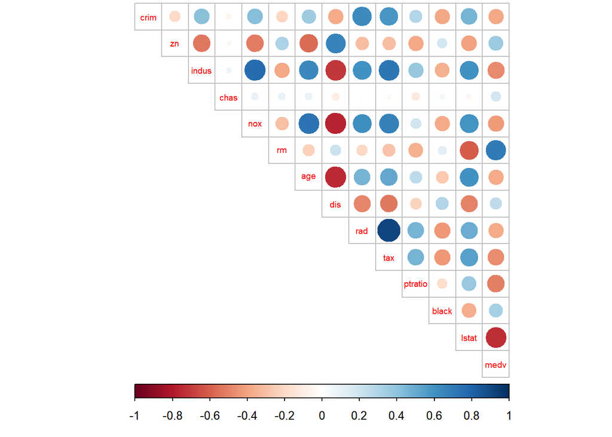

```r
# Calculate the correlation matrix, round it and draw a visualization
cor_matrix <- cor(Boston) %>% round(digits = 2)
corrplot(cor_matrix, method="circle", type="upper", cl.pos = "b", tl.pos = "d", tl.cex = 0.6)
```

# Standardization of the dataset and categorization of variables

The Boston data contains only numerical values, so we can use the function scale() to standardize the whole dataset. In the scaling, we subtract the column means from the corresponding columns and divide the difference with standard deviation. In the data, there will be normal distribution, the mean = 0 and all values indicate a distance from the mean in units of standard deviation.

```r
boston_scaled <- as.data.frame(scale(Boston))
summary(boston_scaled)
```

```
##       crim                 zn               indus
##  Min.   :-0.419367   Min.   :-0.48724   Min.   :-1.5563
##  1st Qu.:-0.410563   1st Qu.:-0.48724   1st Qu.:-0.8668
##  Median :-0.390280   Median :-0.48724   Median :-0.2109
##  Mean   : 0.000000   Mean   : 0.00000   Mean   : 0.0000
##  3rd Qu.: 0.007389   3rd Qu.: 0.04872   3rd Qu.: 1.0150
##  Max.   : 9.924110   Max.   : 3.80047   Max.   : 2.4202
##       chas              nox                rm               age
##  Min.   :-0.2723   Min.   :-1.4644   Min.   :-3.8764   Min.   :-2.3331
##  1st Qu.:-0.2723   1st Qu.:-0.9121   1st Qu.:-0.5681   1st Qu.:-0.8366
##  Median :-0.2723   Median :-0.1441   Median :-0.1084   Median : 0.3171
##  Mean   : 0.0000   Mean   : 0.0000   Mean   : 0.0000   Mean   : 0.0000
##  3rd Qu.:-0.2723   3rd Qu.: 0.5981   3rd Qu.: 0.4823   3rd Qu.: 0.9059
##  Max.   : 3.6648   Max.   : 2.7296   Max.   : 3.5515   Max.   : 1.1164
##       dis               rad               tax             ptratio
##  Min.   :-1.2658   Min.   :-0.9819   Min.   :-1.3127   Min.   :-2.7047
##  1st Qu.:-0.8049   1st Qu.:-0.6373   1st Qu.:-0.7668   1st Qu.:-0.4876
##  Median :-0.2790   Median :-0.5225   Median :-0.4642   Median : 0.2746
##  Mean   : 0.0000   Mean   : 0.0000   Mean   : 0.0000   Mean   : 0.0000
##  3rd Qu.: 0.6617   3rd Qu.: 1.6596   3rd Qu.: 1.5294   3rd Qu.: 0.8058
##  Max.   : 3.9566   Max.   : 1.6596   Max.   : 1.7964   Max.   : 1.6372
##      black             lstat              medv
##  Min.   :-3.9033   Min.   :-1.5296   Min.   :-1.9063
##  1st Qu.: 0.2049   1st Qu.:-0.7986   1st Qu.:-0.5989
##  Median : 0.3808   Median :-0.1811   Median :-0.1449
##  Mean   : 0.0000   Mean   : 0.0000   Mean   : 0.0000
##  3rd Qu.: 0.4332   3rd Qu.: 0.6024   3rd Qu.: 0.2683
##  Max.   : 0.4406   Max.   : 3.5453   Max.   : 2.9865
```

We can create a categorical variable from a continuous one. To categorise our target variable crim (renamed crime):

```r
# Create a quantile vector of crim and create the categorical "crime".
bins <- quantile(boston_scaled$crim)
crime <- cut(boston_scaled$crim, breaks = bins, include.lowest = TRUE, label = c('low','med_low','med_high','high'))
# Remove the original unscaled variable and add the new categorical value to scaled data.
boston_scaled <- dplyr::select(boston_scaled, -crim)
boston_scaled <- data.frame(boston_scaled, crime)
# Look at the table of the new factor crime
table(boston_scaled$crim)
```

```
##
##      low  med_low med_high     high
##      127      126      126      127
```

# Division of the dataset to train and test sets

When we want to use a statistical method to predict something, it is important to have data to test how well the predictions fit. Splitting the original data to test and train sets allows us to check how well our model works. The training of the LDA model is done with the train set and prediction on new data is done with the test set. This way you have true classes / labels for the test data, and you can calculate how well the model performed in prediction. This can be done as follows, choosing randomly 80% of the data to be used for training:

```r
# Number of rows in the Boston dataset
n <- nrow(boston_scaled)
# Choose randomly 80% of the rows
ind <- sample(n,  size = n * 0.8)
# Create train set
train <- boston_scaled[ind,]
# Create test set
test <- boston_scaled[-ind,]
# Save the correct classes from the test data
correct_classes <- test$crime
# Remove the crime variable from the test data
test <- dplyr::select(test, -crime)
```

Linear Discriminant analysis is a classification (and dimension reduction) method. It finds the (linear) combination of the variables that separate the target variable classes. The target can be binary or multiclass variable. Using the divided dataset, it is possible to train the LDA model on the training set:

```r
lda.fit <- lda(crime ~ ., data = train)
lda.fit
```

```
## Call:
## lda(crime ~ ., data = train)
##
## Prior probabilities of groups:
##       low   med_low  med_high      high
## 0.2475248 0.2450495 0.2549505 0.2524752
##
## Group means:
##                   zn      indus        chas        nox          rm
## low       0.84087912 -0.8892223 -0.07547406 -0.8393166  0.44837450
## med_low  -0.05175574 -0.3411361 -0.11325431 -0.5740912 -0.17433815
## med_high -0.38649973  0.1731234  0.26281077  0.4309373  0.07159996
## high     -0.48724019  1.0171096 -0.04073494  1.0355836 -0.42193379
##                 age        dis        rad        tax     ptratio
## low      -0.8500486  0.8100181 -0.6924575 -0.7632571 -0.38362794
## med_low  -0.3532142  0.3970156 -0.5329250 -0.4501888 -0.03218326
## med_high  0.4239200 -0.3780137 -0.4165578 -0.3007276 -0.24494421
## high      0.7917153 -0.8503575  1.6382099  1.5141140  0.78087177
##                black       lstat        medv
## low       0.38295657 -0.76805994  0.55106408
## med_low   0.31616290 -0.11893552 -0.03376977
## med_high  0.08131283  0.04904561  0.12131399
## high     -0.85363469  0.90551643 -0.65296155
##
## Coefficients of linear discriminants:
##                 LD1          LD2           LD3
## zn       0.09777979  0.608611331 -1.0081693912
## indus    0.03647170 -0.204191895  0.2569710290
## chas    -0.06758895 -0.104482617 -0.0008460041
## nox      0.34147288 -0.823737390 -1.2376059695
## rm      -0.10775854 -0.116560970 -0.2282863873
## age      0.23111456 -0.360754096  0.0174064783
## dis     -0.07965391 -0.250837810  0.3022430288
## rad      3.17641613  0.942398435 -0.3111342357
## tax      0.02506455  0.004014085  0.7668521794
## ptratio  0.10852887 -0.011990035 -0.3775545726
## black   -0.11995735  0.007787912  0.1216437646
## lstat    0.21581927 -0.199729719  0.3252968380
## medv     0.18579480 -0.313683822 -0.1640097092
##
## Proportion of trace:
##    LD1    LD2    LD3
## 0.9511 0.0366 0.0122
```

As can be seen in the table above, the 1st linear discriminant (LD1) explains as much as 95 % of the variance, LD2 explaining 4 % and LD3 1 %. The LDA can be visualized with a biplot:

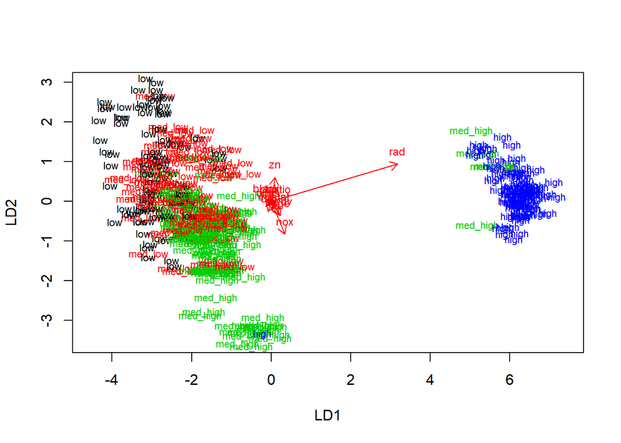

```r
# The function for lda biplot arrows
lda.arrows <- function(x, myscale = 1, arrow_heads = 0.1, color = "red", tex = 0.75, choices = c(1,2)){
  heads <- coef(x)
  arrows(x0 = 0, y0 = 0,
         x1 = myscale * heads[,choices[1]],
         y1 = myscale * heads[,choices[2]], col=color, length = arrow_heads)
  text(myscale * heads[,choices], labels = row.names(heads),
       cex = tex, col=color, pos=3)
}

# Target classes as numeric
classes <- as.numeric(train$crime)

# Plot the lda results
plot(lda.fit, dimen = 2, col = classes, pch = classes)
lda.arrows(lda.fit, myscale = 1)
```

# Predicting with the model

We split our data earlier so that we have the test set and the correct class labels. Let’s have a look on how the LDA model performs when predicting on new (test) data.

```r
# Predict classes with test data
lda.pred <- predict(lda.fit, newdata = test)
# Cross tabulate the results
table(correct = correct_classes, predicted = lda.pred$class)
```

```
##           predicted
## correct    low med_low med_high high
##   low       19       7        1    0
##   med_low    6      13        8    0
##   med_high   1       5       16    1
##   high       0       0        0   25
```

# Clustering

Similarity or dissimilarity of objects can be measured with distance measures. There are many different measures for different types of data. The most common or “normal” distance measure is Euclidean distance, which I will use in the following exercise.

```r
boston_scaled <- as.data.frame(scale(Boston))
# euclidean distance matrix
dist_eu <- dist(boston_scaled)
# look at the summary of the distances
summary(dist_eu)
```

```
##    Min. 1st Qu.  Median    Mean 3rd Qu.    Max.
##  0.1343  3.4625  4.8241  4.9111  6.1863 14.3970
```

Next step is to cluster the data with k-means. In our LDA model, there are four classes, which could be a good choice to start.

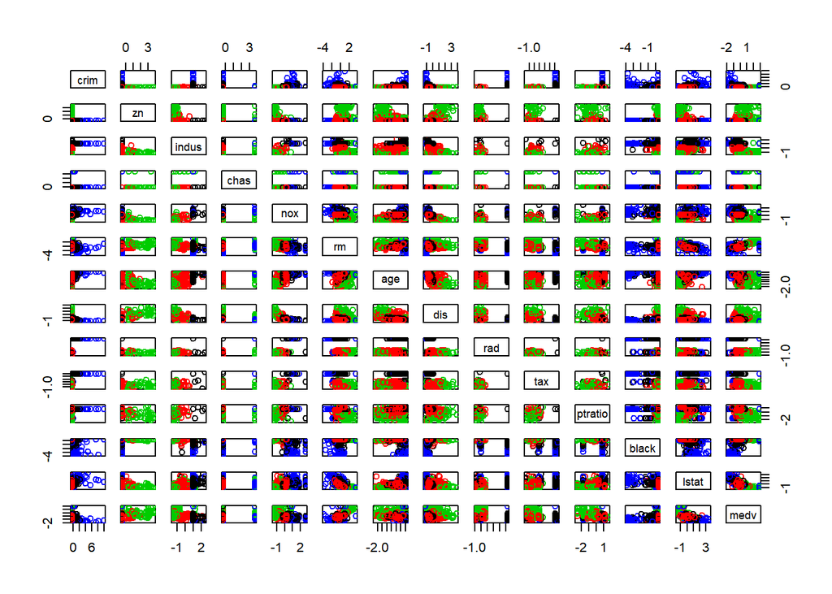

```r
# k-means clustering
km <-kmeans(dist_eu, centers = 4)
# Plot the Boston dataset with clusters
pairs(boston_scaled, col = km$cluster)
```

K-means needs the number of clusters as an argument. There are many ways to look at the optimal number of clusters and a good way might depend on the data you have.

One way to determine the number of clusters is to look at how the total of within cluster sum of squares (WCSS) behaves when the number of cluster changes. When you plot the number of clusters and the total WCSS, the optimal number of clusters is when the total WCSS drops radically.

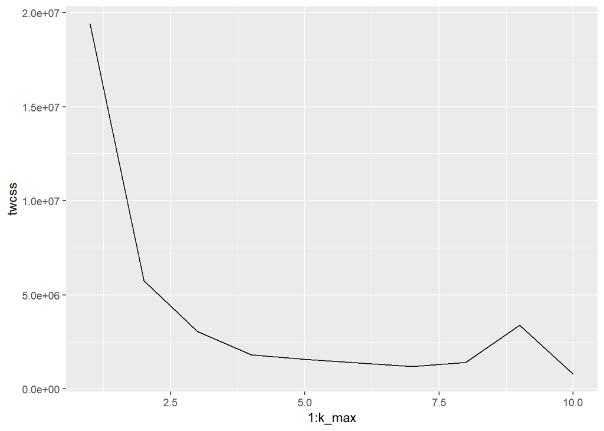

```r
# determine the number of clusters
k_max <- 10
# Calculate the total within sum of squares using the function.
twcss <- sapply(1:k_max, function(k){kmeans(Boston, k)$tot.withinss})

# Visualize the results.
qplot(x = 1:k_max, y = twcss, geom = 'line')
```

The optimal number of cluster is where the TWCSS drops radically. The graphics above showcases that the change happens with two clusters. Let’s cluster the data with two clusters:

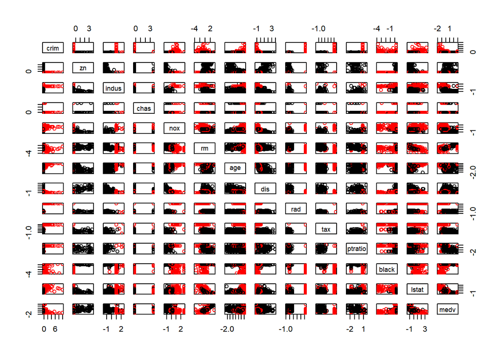

```r
# k-means clustering
km <-kmeans(dist_eu, centers = 2)
# Plot the clusters
pairs(boston_scaled, col = km$cluster)
```

When using euclidian distance, the optimal number of clusters seems to be two.

# Bonus: Perform k-means on the original Boston data with some reasonable number of clusters (> 2)

The Boston data is reloaded and rescaled.

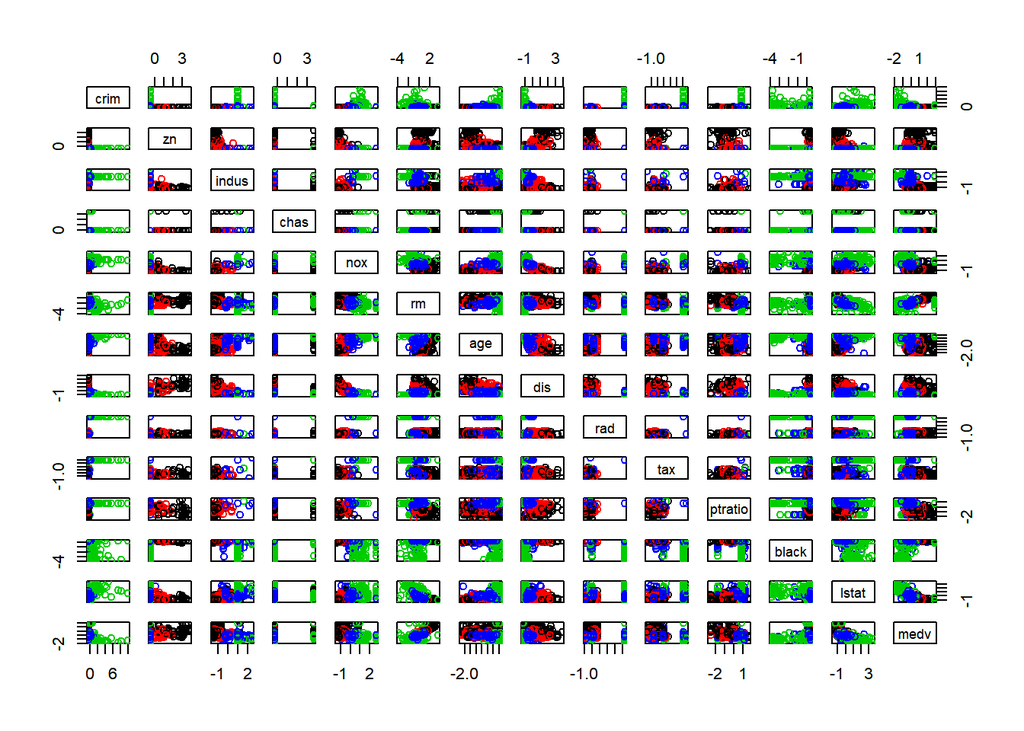

LDA is performed using the clusters as target classes. All the variables in the Boston data are included in the LDA model. The results are visualized with a biplot (arrows are included representing the relationships of the original variables to the LDA solution).

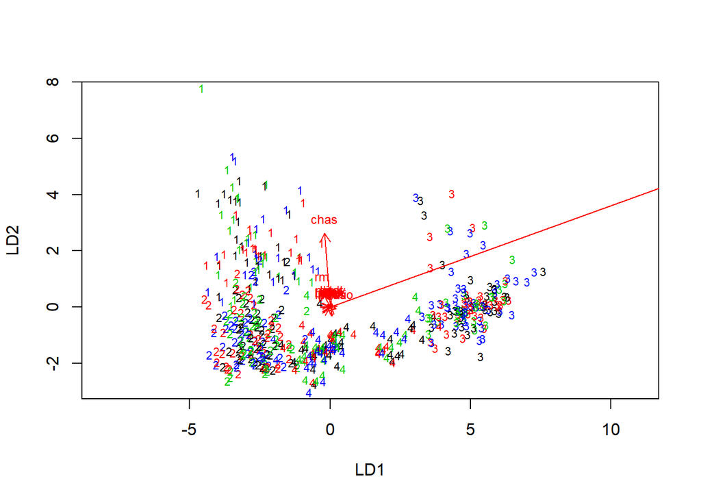

```r
#Perform LDA using the clusters as target classes. Visualize the results with a biplot
lda.fit_2 <- lda(km$cluster ~., data = Boston)
lda.arrows <- function(x, myscale = 1, arrow_heads = 0.1, color = "red", tex = 0.75, choices = c(1,2)){
  heads <- coef(x)
  arrows(x0 = 0, y0 = 0,
         x1 = myscale * heads[,choices[1]],
         y1 = myscale * heads[,choices[2]], col=color, length = arrow_heads)
  text(myscale * heads[,choices], labels = row.names(heads),
       cex = tex, col=color, pos=3)
}
plot(lda.fit_2, dimen = 2, col= classes, pch=classes)
lda.arrows(lda.fit_2, myscale = 1)
```

The graphics above visualize LDA model with the K-means clusters as the target variable. The most influential linear separator is variable nitrogen oxides concentration (nox). The second longiest arrow is variable Charles River dummy variable (chas). For other variables, let’s have a look at the vectors more closely.

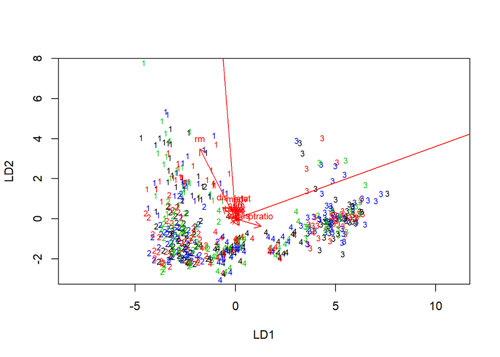

The graphics above showcases that the variables average number of rooms per dwelling (rm) and pupil-teacher ratio by town (ptratio) seem to be linear separators that separate the clusters.

# Exercise 5. Dimensionality reduction techniques

The exercise consists of two parts: the first part is the human data analysis based on United Nations report and the second part is the tea usage analysis based on questionnaire among 300 individuals, the data extracted from R FactoMineR library.

A multidimensional data is challenging to visualizise, so the reduction of variables is often needed to capture the phenomenen behind the data. There are a fairly large selection of statistical methods that can be used to lower the dimensionality of data. In this exercise we use Principal component analysis (PCA) and Multiple correspondence analysis (MCA).

# Human data

## Description of the data

The exercise is based on the dataset, which originates from the United Nations Development Programme. There are two data indices from United Nations Human Development Report:  
Human Development Index (HDI): http://hdr.undp.org/en/composite/HDI  
Gender Inequality Index (GII): http://hdr.undp.org/en/composite/GII  
The original data source: http://s3.amazonaws.com/assets.datacamp.com/production/course_2218/datasets/human1.txt

The orginal dataset has been prepared to our analysis. The indices HDI and GII have been joined by variable country and two additional variables have been calculated using existing variables of the dataset. Variable GNI has been transformed to numeric and some unneeded variables have been removed. The observations with missing values and those related to regions have been removed. The data contains 155 observations and 8 variables.

The variables are

- edu2_f_m = Proportion of females with at least secondary education / Proportion of males with at least secondary education
- labo_f_m = Proportion of females in the labour force / Proportion of males in the labour force
- edu_exp = Expected years of education
- life_exp = Life expectancy at birth
- gni_cap = Gross national income per capita (2011 PPP $)
- mat_mor = Maternal mortality rate (deaths per 100,000 live births)
- ado_birth = Adolescent birth rate (births per 1,000 women ages 15-19)
- parli_f = Percetange of female representatives in parliament (% held by women)

To read the data in.

```r
human <- as.data.frame(read.table('data/human.csv',  sep="\t", header=TRUE))
```

Summary of data is generated by function glimpse:

```r
glimpse(human)
```

```
## Observations: 155
## Variables: 8
## $ edu2_f_m  <dbl> 1.0072389, 0.9968288, 0.9834369, 0.9886128, 0.969060...
## $ labo_f_m  <dbl> 0.8908297, 0.8189415, 0.8251001, 0.8840361, 0.828611...
## $ edu_exp   <dbl> 17.5, 20.2, 15.8, 18.7, 17.9, 16.5, 18.6, 16.5, 15.9...
## $ life_exp  <dbl> 81.6, 82.4, 83.0, 80.2, 81.6, 80.9, 80.9, 79.1, 82.0...
## $ gni_cap   <int> 64992, 42261, 56431, 44025, 45435, 43919, 39568, 529...
## $ mat_mor   <int> 4, 6, 6, 5, 6, 7, 9, 28, 11, 8, 6, 4, 8, 4, 27, 2, 1...
## $ ado_birth <dbl> 7.8, 12.1, 1.9, 5.1, 6.2, 3.8, 8.2, 31.0, 14.5, 25.3...
## $ parli_f   <dbl> 39.6, 30.5, 28.5, 38.0, 36.9, 36.9, 19.9, 19.4, 28.2...
```

To showcase a graphical overview of the data and summaries of the variables in the data, ggpairs and summary functions are carried out:

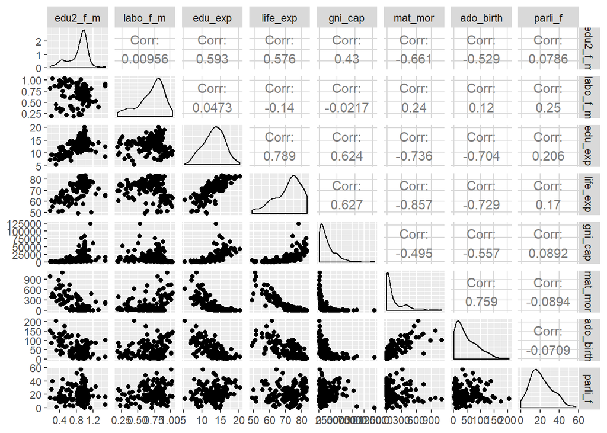

```r
p <- ggpairs(human, lower = list(combo = wrap("facethist", bins = 20)))
p
```

```r
summary(human)
```

```
##     edu2_f_m         labo_f_m         edu_exp         life_exp
##  Min.   :0.1717   Min.   :0.1857   Min.   : 5.40   Min.   :49.00
##  1st Qu.:0.7264   1st Qu.:0.5984   1st Qu.:11.25   1st Qu.:66.30
##  Median :0.9375   Median :0.7535   Median :13.50   Median :74.20
##  Mean   :0.8529   Mean   :0.7074   Mean   :13.18   Mean   :71.65
##  3rd Qu.:0.9968   3rd Qu.:0.8535   3rd Qu.:15.20   3rd Qu.:77.25
##  Max.   :1.4967   Max.   :1.0380   Max.   :20.20   Max.   :83.50
##     gni_cap          mat_mor         ado_birth         parli_f
##  Min.   :   581   Min.   :   1.0   Min.   :  0.60   Min.   : 0.00
##  1st Qu.:  4198   1st Qu.:  11.5   1st Qu.: 12.65   1st Qu.:12.40
##  Median : 12040   Median :  49.0   Median : 33.60   Median :19.30
##  Mean   : 17628   Mean   : 149.1   Mean   : 47.16   Mean   :20.91
##  3rd Qu.: 24512   3rd Qu.: 190.0   3rd Qu.: 71.95   3rd Qu.:27.95
##  Max.   :123124   Max.   :1100.0   Max.   :204.80   Max.   :57.50
```

The distribution of most of the variables is rather biased. The exceptions are variable Expected years of education (edu_exp) and the gender ratio with at least secondary education (edu2_f_m), which are rather close to the normal distribution. The scatterplots showcase that there are outliers in plots e.g. variable gni_cap. The range of the variables varies a lot, for instance variable gni_cap from 581 to 123124 and life expantancy from 49 to 83.5.

To showcase the relationship between the variables, corrplot function is conducted:

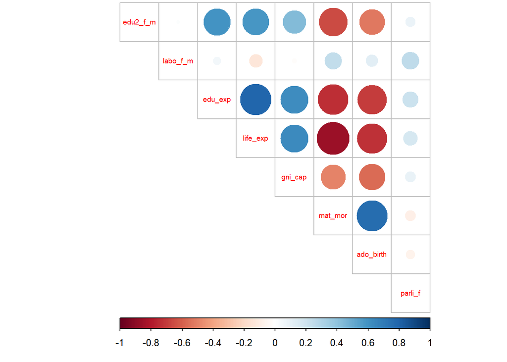

```r
cor_matrix <- cor(human) %>% round(digits = 2)
corrplot(cor_matrix, method="circle", type="upper", cl.pos = "b", tl.pos = "d", tl.cex = 0.6)
```

The correlation plot shows that some variables correlate strongly with each other. The strong negative correlation (-0.857) is between life expectancy and maternal mortality rate. The strong positive correlation is between life expectancy and education expectancy (0.789) and between adolescent birth rate and maternal mortality (0.759).

# Principal component analysis (PCA)

```r
pca_human <- prcomp(human)
p_human_notstd <- summary(pca_human)
p_human_notstd
```

```
## Importance of components:
##                              PC1      PC2   PC3   PC4   PC5   PC6    PC7
## Standard deviation     1.854e+04 185.5219 25.19 11.45 3.766 1.566 0.1912
## Proportion of Variance 9.999e-01   0.0001  0.00  0.00 0.000 0.000 0.0000
## Cumulative Proportion  9.999e-01   1.0000  1.00  1.00 1.000 1.000 1.0000
##                           PC8
## Standard deviation     0.1591
## Proportion of Variance 0.0000
## Cumulative Proportion  1.0000
```

The summary above showcases that the first principal component PC1 explains nearly all of the variance (proportion of variance 9.999e-01, PC2 0.0001). The bilpot drawing generates a list of errors related to arrows which the program cannot draw properly.

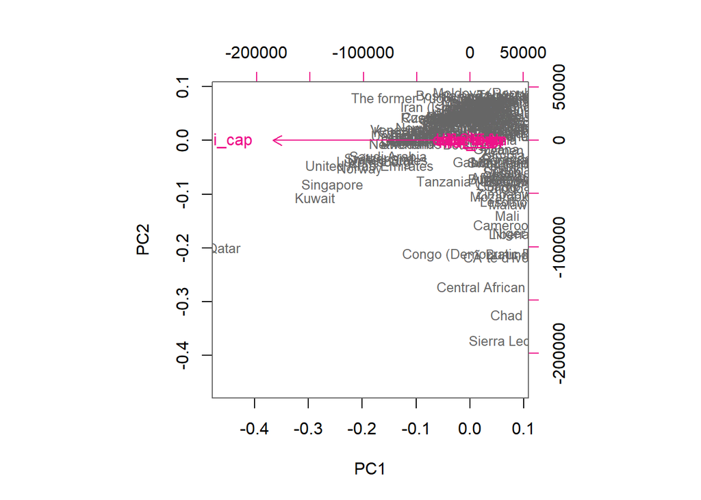

```r
biplot(pca_human, choices = 1:2, cex = c(0.8, 1), col = c("grey40", "deeppink2"))
```

Based on the course’s learning material, PCA is sensitive to the relative scaling of the original features and assumes that features with larger variance are more important than features with smaller variance. The variable gni_cap stands out of from other variables. The gni_cap is on totally different scale than other variables and as earlier stated there are some outliers that can detected in the scatterplot. Standardization of the features before PCA is needed. After standardising the variables, the results look different:

```r
# Standardisation of the variables
human_std <- scale(human)
pca_human_std <- prcomp(human_std)
s_human_std <- summary(pca_human_std)
s_human_std
```

```
## Importance of components:
##                           PC1    PC2     PC3     PC4     PC5     PC6
## Standard deviation     2.0708 1.1397 0.87505 0.77886 0.66196 0.53631
## Proportion of Variance 0.5361 0.1624 0.09571 0.07583 0.05477 0.03595
## Cumulative Proportion  0.5361 0.6984 0.79413 0.86996 0.92473 0.96069
##                            PC7     PC8
## Standard deviation     0.45900 0.32224
## Proportion of Variance 0.02634 0.01298
## Cumulative Proportion  0.98702 1.00000
```

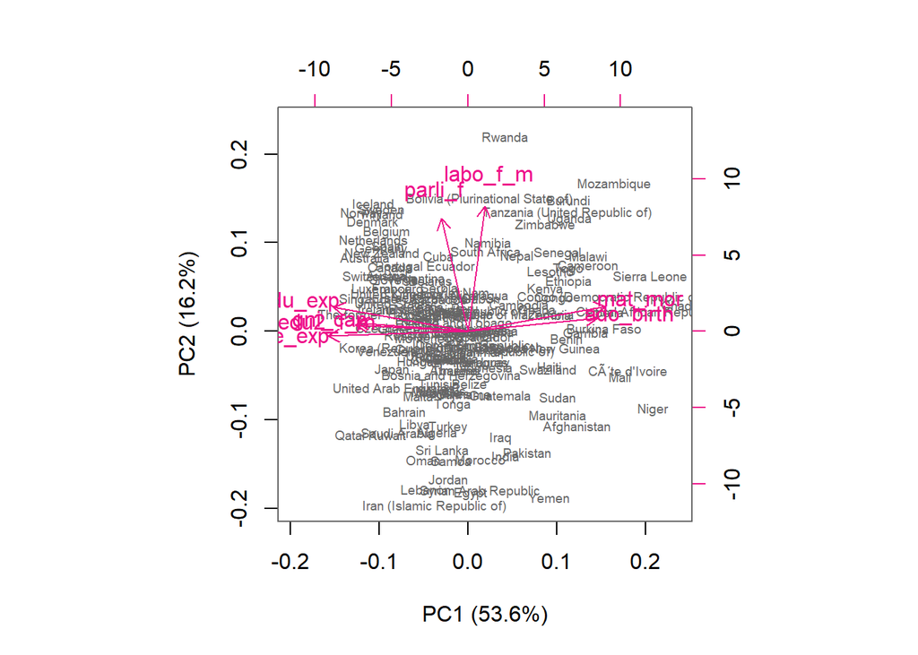

```r
# Percentages of variance for the plot titles
pr_shs <- round(100*s_human_std$importance[2, ], digits = 1)
pc_shs_lab <- paste0(names(pr_shs), " (", pr_shs, "%)")
biplot(pca_human_std, choices = 1:2, cex = c(0.6, 1), col = c("grey40", "deeppink2"), xlab = pc_shs_lab[1], ylab = pc_shs_lab[2])
```

Based on my biplot, the relationships are not clear enough, so I generated a summary of relationship (correlation or anticorrelation, etc) between the initial variables and the principal components ($rotation):

```r
pca_human_std$rotation
```

```
##                   PC1         PC2         PC3         PC4        PC5
## edu2_f_m  -0.35664370  0.03796058 -0.24223089  0.62678110 -0.5983585
## labo_f_m   0.05457785  0.72432726 -0.58428770  0.06199424  0.2625067
## edu_exp   -0.42766720  0.13940571 -0.07340270 -0.07020294  0.1659678
## life_exp  -0.44372240 -0.02530473  0.10991305 -0.05834819  0.1628935
## gni_cap   -0.35048295  0.05060876 -0.20168779 -0.72727675 -0.4950306
## mat_mor    0.43697098  0.14508727 -0.12522539 -0.25170614 -0.1800657
## ado_birth  0.41126010  0.07708468  0.01968243  0.04986763 -0.4672068
## parli_f   -0.08438558  0.65136866  0.72506309  0.01396293 -0.1523699
##                   PC6         PC7         PC8
## edu2_f_m   0.17713316  0.05773644  0.16459453
## labo_f_m  -0.03500707 -0.22729927 -0.07304568
## edu_exp   -0.38606919  0.77962966 -0.05415984
## life_exp  -0.42242796 -0.43406432  0.62737008
## gni_cap    0.11120305 -0.13711838 -0.16961173
## mat_mor    0.17370039  0.35380306  0.72193946
## ado_birth -0.76056557 -0.06897064 -0.14335186
## parli_f    0.13749772  0.00568387 -0.02306476
```

# Interpretations of the PCA results on the standardized human data

The first principal component PCA1 explains 53.6% and the second principal component PCA2 explains 16.2% the variance of the eight variables.

Based on the biplot and the summary above, it can be concluded that the first component PC1 represents the variables that are related to the living conditions and welfare and the second component PCA2 is related to equality questions. Based on graphics these issues are not correlated.

The first component represents variables maternal mortality (mat_mor) and the adolescent birth rate (ado_birth), which are positively correlated. The data indicates that maternal mortality rate is high in the teenage pregnancies and the living conditions explain the phenomena.

Other variables that are related to the first component and correlate positively with each other are expected level of education (edu_exp), the ratio of percentages of females vs. males with secondary education (edu2_f_m ), life expectancy at birth (life_exp) and gross national income per capita (gni_cap).

The second component PCA2 is related to the equality issues. The biplot showcases strong postitive correlation between the variables ratio of females vs. males in the labour force (labo_f_m) and the percetange of female representatives in parliament (parli_f).

Let’s take some examples of the data. Based on the data and the biplot above, the rate of maternal mortality and teenage pregnancies are high in Mosambique. On the other hand, the women in Mosambique are active in politics and the ratio female vs. male in the labour market shows that women participate actively in the labour market.

In Qatar, there are more women with at least secondary education than men, the life expentancy rate is high, and gross national income is high, but there are no women in the parliament.

The examples indicate that the components PCA1 and PCA2 are not correlated as was stated based on the biplot. As whole, the living conditions explain the most variability of the data.

# Multiple Correspondence Analysis (MCA) on the tea data

The tea data analysis is based on questionnaire data on tea usage among 300 individuals, extracted from R FactoMineR library. The description of the questionnaire in the library: The data used here concern a questionnaire on tea. We asked to 300 individuals how they drink tea (18 questions), what are their product’s perception (12 questions) and some personal details (4 questions). The first 18 questions are active ones, the 19th is a supplementary quantitative variable (the age) and the last variables are supplementary categorical variables.

To load the data:

```r
library(FactoMineR)
data(tea)
```

Let’s have a look on the data by using glimpse function:

```r
glimpse(tea)
```

```
## Observations: 300
## Variables: 36
## $ breakfast        <fct> breakfast, breakfast, Not.breakfast, Not.brea...
## $ tea.time         <fct> Not.tea time, Not.tea time, tea time, Not.tea...
## $ evening          <fct> Not.evening, Not.evening, evening, Not.evenin...
## $ lunch            <fct> Not.lunch, Not.lunch, Not.lunch, Not.lunch, N...
## $ dinner           <fct> Not.dinner, Not.dinner, dinner, dinner, Not.d...
## $ always           <fct> Not.always, Not.always, Not.always, Not.alway...
## $ home             <fct> home, home, home, home, home, home, home, hom...
## $ work             <fct> Not.work, Not.work, work, Not.work, Not.work,...
## $ tearoom          <fct> Not.tearoom, Not.tearoom, Not.tearoom, Not.te...
## $ friends          <fct> Not.friends, Not.friends, friends, Not.friend...
## $ resto            <fct> Not.resto, Not.resto, resto, Not.resto, Not.r...
## $ pub              <fct> Not.pub, Not.pub, Not.pub, Not.pub, Not.pub, ...
## $ Tea              <fct> black, black, Earl Grey, Earl Grey, Earl Grey...
```

[output cut: 23 more lines]

All variables are of categorial type. To showcase a graphical overview of the data and of the variables in the data, I tried to use “ggpairs” fundtion but the program was not able to carry out the task. Therefore I create a new dataset called tea2 and choose variables that could explain the usage of tea: Where do the people buy tea, do they use teabags and other aspects of the tea usage.

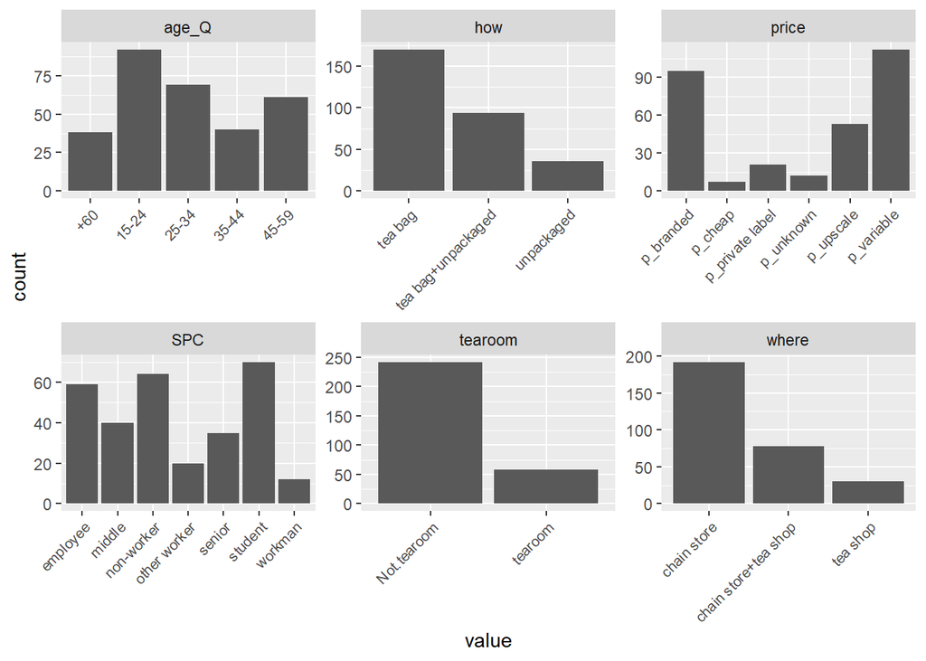

```r
keep2 <- c("age_Q", "where", "SPC", "price", "how", "tearoom")
tea2 <- dplyr::select(tea, one_of(keep2))
gather(tea2) %>% ggplot(aes(value)) +
facet_wrap("key", scales = "free") +
geom_bar() +
theme(axis.text.x = element_text(angle = 45, hjust = 1, size = 8))
```

Let’s carry out an MCA for the data and summarise the model:

```r
mca <- MCA(tea2)
```

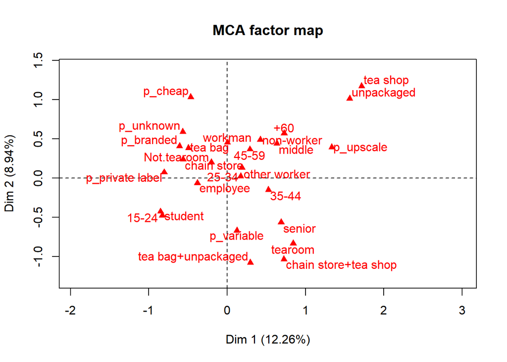

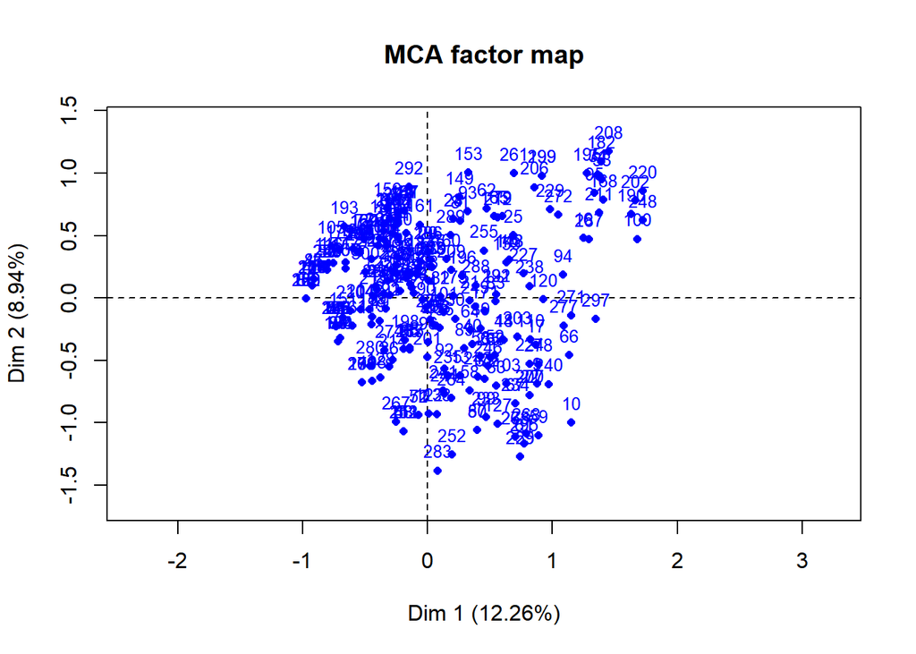

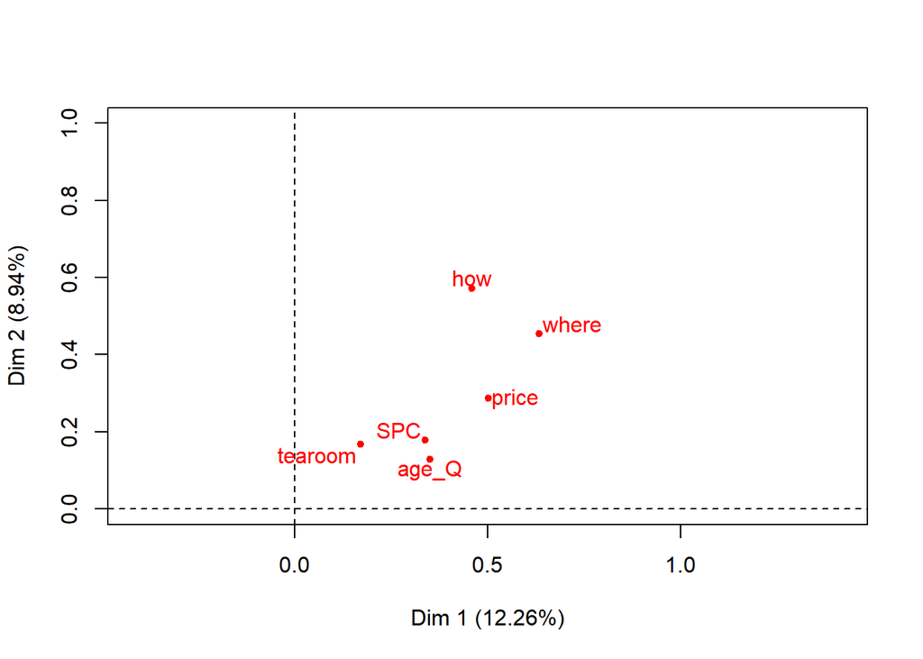

```r
# summary of the model
summary(mca)
```

```
##
## Call:
## MCA(X = tea2)
##
##
## Eigenvalues
##                        Dim.1   Dim.2   Dim.3   Dim.4   Dim.5   Dim.6
## Variance               0.409   0.298   0.290   0.243   0.208   0.200
## % of var.             12.260   8.938   8.703   7.286   6.226   6.005
## Cumulative % of var.  12.260  21.199  29.902  37.188  43.414  49.419
##                        Dim.7   Dim.8   Dim.9  Dim.10  Dim.11  Dim.12
## Variance               0.179   0.176   0.173   0.163   0.157   0.145
## % of var.              5.357   5.282   5.189   4.882   4.704   4.360
## Cumulative % of var.  54.776  60.057  65.246  70.128  74.833  79.193
##                       Dim.13  Dim.14  Dim.15  Dim.16  Dim.17  Dim.18
## Variance               0.138   0.120   0.109   0.087   0.080   0.059
## % of var.              4.144   3.588   3.269   2.617   2.404   1.782
## Cumulative % of var.  83.337  86.926  90.195  92.812  95.217  96.999
##                       Dim.19  Dim.20
## Variance               0.053   0.047
## % of var.              1.589   1.412
## Cumulative % of var.  98.588 100.000
##
## Individuals (the 10 first)
##                         Dim.1    ctr   cos2    Dim.2    ctr   cos2
## 1                    | -0.173  0.024  0.005 |  0.519  0.301  0.042 |
## 2                    | -0.055  0.002  0.001 |  0.292  0.096  0.038 |
## 3                    | -0.171  0.024  0.008 |  0.198  0.044  0.011 |
## 4                    | -0.734  0.439  0.367 | -0.231  0.060  0.036 |
## 5                    | -0.319  0.083  0.054 |  0.138  0.021  0.010 |
## 6                    | -0.975  0.776  0.280 | -0.004  0.000  0.000 |
## 7                    |  0.021  0.000  0.000 | -0.173  0.033  0.010 |
## 8                    |  0.007  0.000  0.000 |  0.134  0.020  0.007 |
## 9                    |  0.879  0.630  0.193 | -0.685  0.525  0.117 |
## 10                   |  1.151  1.080  0.284 | -1.002  1.122  0.215 |
##                       Dim.3    ctr   cos2
## 1                     0.756  0.656  0.089 |
## 2                     0.349  0.140  0.053 |
## 3                     0.329  0.124  0.031 |
## 4                    -0.070  0.006  0.003 |
```

[output cut: 24 more lines]

```
## +60                    0.047   3.757 |  -2.167  34.167   0.681 -14.269 |
## chain store            0.101   5.502 |   0.056   0.117   0.006   1.299 |
## chain store+tea shop   0.379 -10.648 |  -0.410   2.516   0.059  -4.207 |
## tea shop               0.153   6.765 |   0.706   2.867   0.055   4.072 |
## employee               0.001  -0.549 |   0.428   2.067   0.045   3.659 |
## middle                 0.030   2.986 |   0.804   4.957   0.100   5.456 |
##
## Categorical variables (eta2)
##                        Dim.1 Dim.2 Dim.3
## age_Q                | 0.350 0.128 0.775 |
## where                | 0.633 0.455 0.096 |
## SPC                  | 0.338 0.178 0.753 |
## price                | 0.501 0.287 0.069 |
## how                  | 0.459 0.573 0.041 |
## tearoom              | 0.170 0.167 0.008 |
```

The summary showcases that the dimensions don’t explain a large proportion of the total variance. There are no strong relations between the dimensions and the variables. The situation by the plot:

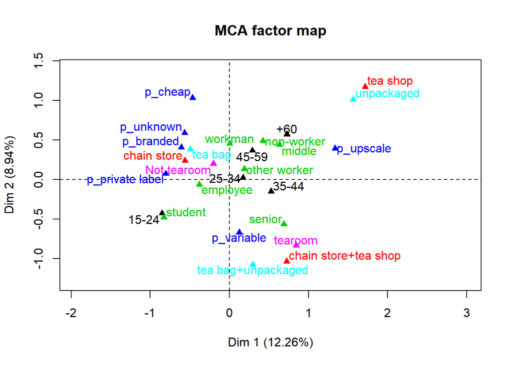

```r
# visualize MCA
plot(mca, invisible=c("ind"), habillage = "quali")
```

The plot showcases the variables *where* and *how* are related to the DIM1. The both variables are related to DIM2 too. Several other variables are related to both dimensions.

Based on the plot, we can assume that there are persons who tend to buy unpackaged tea in the specialized tea shops and those who buy tea bags at the chain stores. The analysis demonstrates that there is no clear overall pattern of the tea usage in this data. ***

# Exercise 6. Analysis of longitudinal data

This exercise consists of two parts: Part 1. Analysis of RATS data and Part 2. Analysis of BPRS data. The task in this exercise is to analyse the datasets using statistical methods suitable for analysis for longitudinal data. The longitudinal data is collected over a long time period, with several observations per subject.

In Part 1. some useful methods for the graphical exploration of this type of data and simple Summary Measure Approach is applied to RATS data. In Part 2. Linear Mixed Effects Models are applied to BPRS data.

The data are provided by Kimmo Vehkalahti and found here https://raw.githubusercontent.com/KimmoVehkalahti/MABS/master/Examples/data/BPRS.txt https://raw.githubusercontent.com/KimmoVehkalahti/MABS/master/Examples/data/rats.txt

The source material for this exercise is provided by course: Selected excerpts of the forthcoming book (Vehkalahti and Everitt, 2019), Chapter 8 Analysis of Longitudinal Data I: Graphical Displays and Summary Measure Approach and Chapter 9 Analysis of Longitudinal Data II: Linear Mixed Effects Models for Normal Response Variables.

# PART 1. Analysis of RATS data

## Description of the data

The data is from a nutrition study conducted in three groups of rats. The three groups were put on different diets, and each animal’s body weight (grams) was recorded repeatedly (approximately weekly, except in week seven when two recordings were taken) over a 9-week period. The question of most interest is whether the growth profiles of the three groups differ. The data have been converted into a long format.

The data is loaded in:

```r
#Read the RATS data into R
RATS <- read.table("https://raw.githubusercontent.com/KimmoVehkalahti/MABS/master/Examples/data/rats.txt", header = TRUE, sep  ='\t')
```

To glimpse the dataset and the categorial variables are converted to factors.

```r
# Glimpse the data}
# Convert the categorical variables of data set to factors
RATS$ID <- factor(RATS$ID)
RATS$Group <- factor(RATS$Group)
glimpse(RATS)
```

```
## Observations: 16
## Variables: 13
## $ ID    <fct> 1, 2, 3, 4, 5, 6, 7, 8, 9, 10, 11, 12, 13, 14, 15, 16
## $ Group <fct> 1, 1, 1, 1, 1, 1, 1, 1, 2, 2, 2, 2, 3, 3, 3, 3
## $ WD1   <int> 240, 225, 245, 260, 255, 260, 275, 245, 410, 405, 445, 5...
## $ WD8   <int> 250, 230, 250, 255, 260, 265, 275, 255, 415, 420, 445, 5...
## $ WD15  <int> 255, 230, 250, 255, 255, 270, 260, 260, 425, 430, 450, 5...
## $ WD22  <int> 260, 232, 255, 265, 270, 275, 270, 268, 428, 440, 452, 5...
## $ WD29  <int> 262, 240, 262, 265, 270, 275, 273, 270, 438, 448, 455, 5...
## $ WD36  <int> 258, 240, 265, 268, 273, 277, 274, 265, 443, 460, 455, 5...
## $ WD43  <int> 266, 243, 267, 270, 274, 278, 276, 265, 442, 458, 451, 5...
## $ WD44  <int> 266, 244, 267, 272, 273, 278, 271, 267, 446, 464, 450, 5...
## $ WD50  <int> 265, 238, 264, 274, 276, 284, 282, 273, 456, 475, 462, 6...
## $ WD57  <int> 272, 247, 268, 273, 278, 279, 281, 274, 468, 484, 466, 6...
## $ WD64  <int> 278, 245, 269, 275, 280, 281, 284, 278, 478, 496, 472, 6...
```

To convert the data to long form.

```r
# Convert to long form
RATSL <- RATS %>%
  gather(key = WD, value = Weight, -ID, -Group) %>%
  mutate(Time = as.integer(substr(WD,3,4)))
```

To glimpse of the dataset.

```r
# Look at the structure of dataset
glimpse(RATSL)
```

```
## Observations: 176
## Variables: 5
## $ ID     <fct> 1, 2, 3, 4, 5, 6, 7, 8, 9, 10, 11, 12, 13, 14, 15, 16, ...
## $ Group  <fct> 1, 1, 1, 1, 1, 1, 1, 1, 2, 2, 2, 2, 3, 3, 3, 3, 1, 1, 1...
## $ WD     <chr> "WD1", "WD1", "WD1", "WD1", "WD1", "WD1", "WD1", "WD1",...
## $ Weight <int> 240, 225, 245, 260, 255, 260, 275, 245, 410, 405, 445, ...
## $ Time   <int> 1, 1, 1, 1, 1, 1, 1, 1, 1, 1, 1, 1, 1, 1, 1, 1, 8, 8, 8...
```

The plot shows the rat growth profiles by three groups for the RATS data over nine weeks.

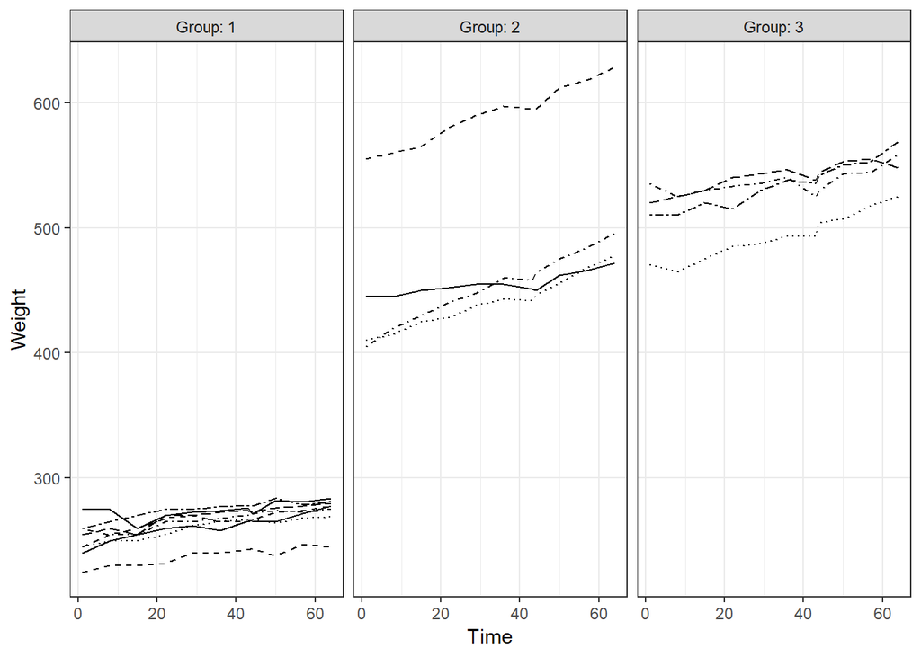

```r
ggplot(RATSL, aes(x = Time, y = Weight, linetype = ID))+
  geom_line() + scale_linetype_manual(values = rep(1:10, times=4))+
  facet_grid(. ~ Group, labeller = label_both)+
  theme_bw() + theme(legend.position = "none")+
  theme(panel.grid.minor.y = element_blank()) +
  scale_y_continuous(limits = c(min(RATSL$Weight), max(RATSL$Weight)))
```

The graphics above showcases that the weights of the rats in the first group are much lower than the weights of rats in the other groups. In all groups, there seem to be possibly an outlier. The weight score of almost all the rats is increasing over the nine weeks of the study. The rats which have higher weight values at the beginning tend to have higher values throughout the study. This phenomenon is generally referred to as *tracking*.

```r
# Standardise the variable weight
RATSL <- RATSL %>%
  group_by(Time) %>%
  mutate(stdweight = Weight) %>%
  ungroup()
```

```r
# Glimpse the data
glimpse(RATSL)
```

```
## Observations: 176
## Variables: 6
## $ ID        <fct> 1, 2, 3, 4, 5, 6, 7, 8, 9, 10, 11, 12, 13, 14, 15, 1...
## $ Group     <fct> 1, 1, 1, 1, 1, 1, 1, 1, 2, 2, 2, 2, 3, 3, 3, 3, 1, 1...
## $ WD        <chr> "WD1", "WD1", "WD1", "WD1", "WD1", "WD1", "WD1", "WD...
## $ Weight    <int> 240, 225, 245, 260, 255, 260, 275, 245, 410, 405, 44...
## $ Time      <int> 1, 1, 1, 1, 1, 1, 1, 1, 1, 1, 1, 1, 1, 1, 1, 1, 8, 8...
## $ stdweight <int> 240, 225, 245, 260, 255, 260, 275, 245, 410, 405, 44...
```

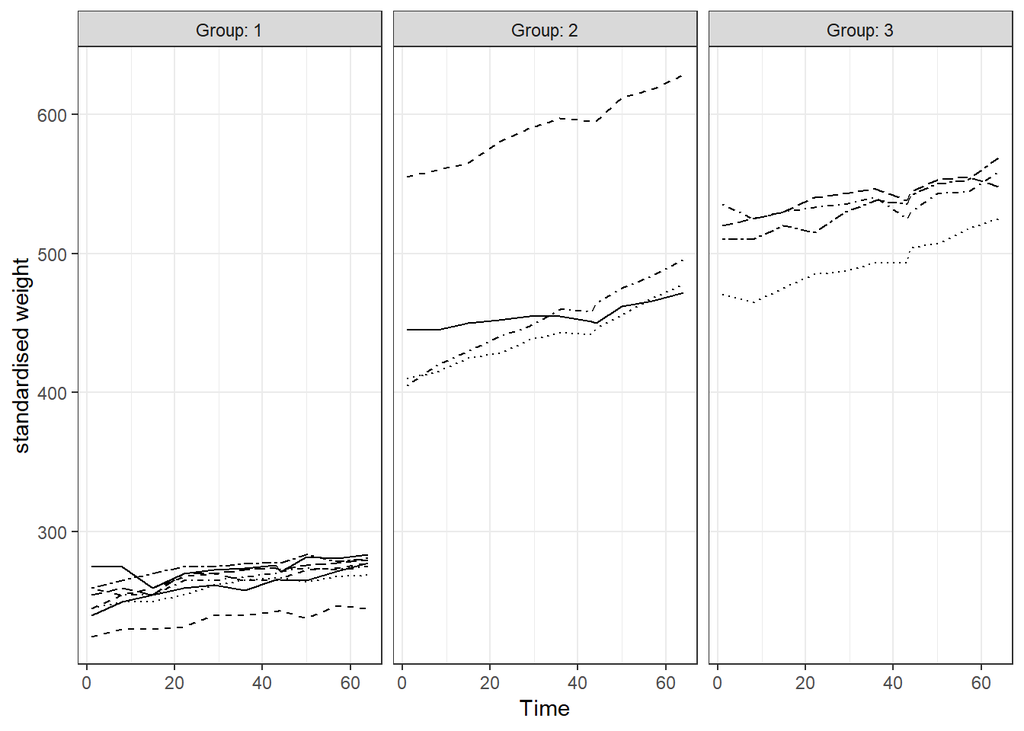

```r
ggplot(RATSL, aes(x = Time, y = stdweight, linetype = ID)) +
  geom_line() + scale_linetype_manual(values = rep(1:10, times=4))+
  facet_grid(. ~ Group, labeller = label_both)+
  theme_bw() + theme(legend.position = "none")+
  theme(panel.grid.minor.y = element_blank())+
  scale_y_continuous(name = "standardised weight")
```

It is often useful to produce graphs showing average (mean) profiles for each group instead of the individual profiles.

```r
# Number of weeks, baseline (week 0) included
n <- RATSL$Time %>% unique() %>% length()
```

```r
# Summary data with mean and standard error of weight by group and time
RATSS <- RATSL %>%
  group_by(Group, Time) %>%
  summarise(mean = mean(Weight), sd = sd(Weight)) %>%
  ungroup()
```

Let’s have a look at the new dataset.

```r
# Glimpse the data
glimpse(RATSS)
```

```
## Observations: 33
## Variables: 4
## $ Group <fct> 1, 1, 1, 1, 1, 1, 1, 1, 1, 1, 1, 2, 2, 2, 2, 2, 2, 2, 2,...
## $ Time  <int> 1, 8, 15, 22, 29, 36, 43, 44, 50, 57, 64, 1, 8, 15, 22, ...
## $ mean  <dbl> 250.625, 255.000, 254.375, 261.875, 264.625, 265.000, 26...
## $ sd    <dbl> 15.22158, 13.09307, 11.47591, 13.60081, 11.05748, 11.783...
```

The next plot showcases the mean rat growth profiles for the three groups in the RATS data.

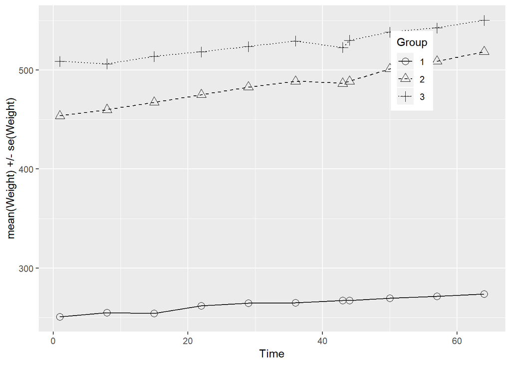

```r
# Plot the mean profiles
ggplot(RATSS, aes(x = Time, y = mean, linetype = Group, shape = Group)) +
  geom_line() +
  scale_linetype_manual(values = c(1,2,3)) +
  geom_point(size=3) +
  scale_shape_manual(values = c(1,2,3)) +
  #geom_errorbar(aes(ymin=mean-se, ymax=mean+se, linetype="1"), width=0.3) +
  theme(legend.position = c(0.8,0.8)) +
  scale_y_continuous(name = "mean(Weight) +/- se(Weight)")
```

There is no overlap in the mean profiles of the three groups suggesting that there is difference between the three groups with respect to the mean weight values.

## Summary Measure Approach

The next plot suggests the presence of some possible outliers at a number of time points. Let’s create a summary data by groups and individuals with mean as the summary variable. The observations after the first measurement are included.

```r
# Create a summary data by Group and ID with mean as the summary variable (ignoring baseline day 1).
RATSL8S <- RATSL %>%
  filter(Time > 1) %>%
  group_by(Group, ID) %>%
  summarise( mean=mean(Weight) ) %>%
  ungroup()
```

Let’s glimpse the dataset.

```r
# Glimpse the data
glimpse(RATSL8S)
```

```
## Observations: 16
## Variables: 3
## $ Group <fct> 1, 1, 1, 1, 1, 1, 1, 1, 2, 2, 2, 2, 3, 3, 3, 3
## $ ID    <fct> 1, 2, 3, 4, 5, 6, 7, 8, 9, 10, 11, 12, 13, 14, 15, 16
## $ mean  <dbl> 263.2, 238.9, 261.7, 267.2, 270.9, 276.2, 274.6, 267.5, ...
```

```r
RATSL8S$mean
```

```
##  [1] 263.2 238.9 261.7 267.2 270.9 276.2 274.6 267.5 443.9 457.5 455.8
## [12] 594.0 495.2 536.4 542.2 536.2
```

The boxplot of all groups reveals outliers. They are the lowest values in the group 1 and 3 and the highest value in the group 2. The outliers might bias the conclusions from further comparisons of the groups, so we shall remove these subjects from the data.

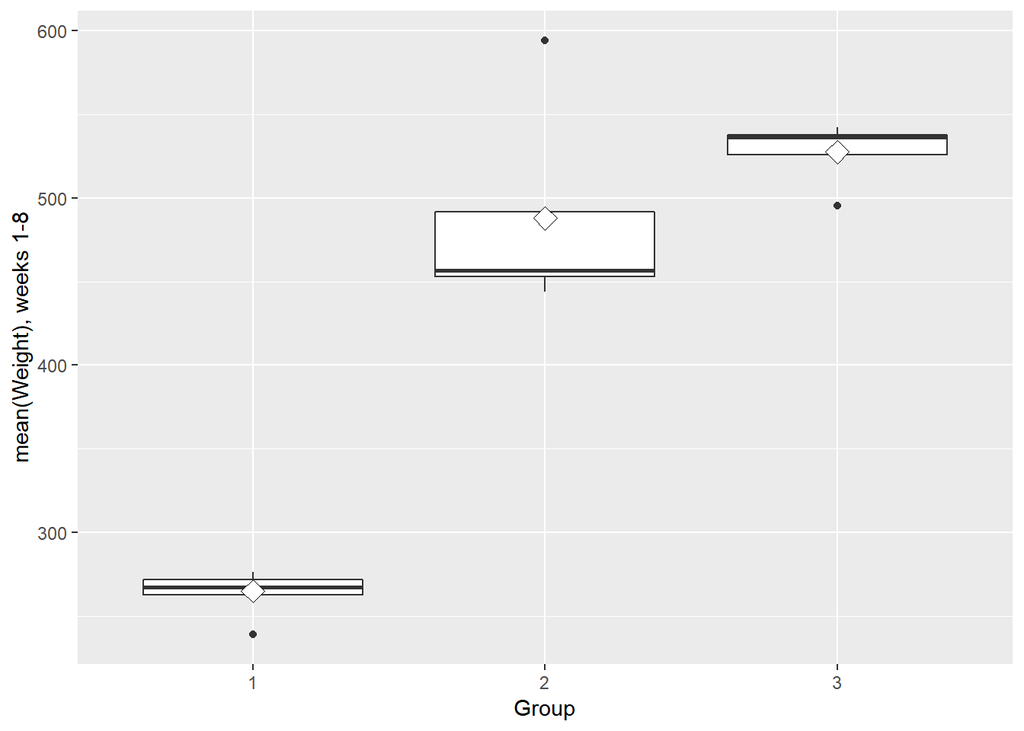

```r
# Draw a boxplot of the mean versus group
ggplot(RATSL8S, aes(x = Group, y = mean)) +
  geom_boxplot() +
  stat_summary(fun.y = "mean", geom = "point", shape=23, size=4, fill = "white") +
  scale_y_continuous(name = "mean(Weight), weeks 1-8")
```

The boxplot without the outliers.

```r
# Create a new data by filtering the outlier and adjust the ggplot code the draw the plot again with the new data
RATSL8S1 <- filter(RATSL8S, mean != 238.9, mean != 594.0, mean != 495.2)
RATSL8S1$mean
```

```
##  [1] 263.2 261.7 267.2 270.9 276.2 274.6 267.5 443.9 457.5 455.8 536.4
## [12] 542.2 536.2
```

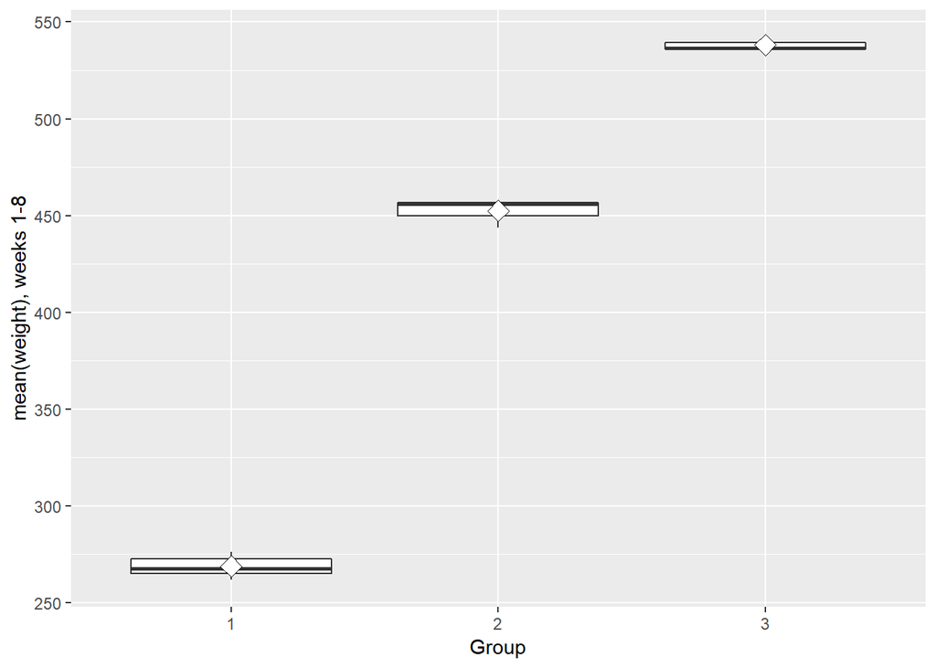

```r
ggplot(RATSL8S1, aes(x = Group, y = mean)) +
  geom_boxplot() +
  stat_summary(fun.y = "mean", geom = "point", shape=23, size=4, fill = "white") +
  scale_y_continuous(name = "mean(weight), weeks 1-8")
```

The baseline will be added to the summary data as a new variable.

```r
# Add the baseline from the original data as a new variable to the summary data
RATSL8S2 <- RATSL8S %>%
  mutate(baseline = RATS$WD1)
```

```r
# Fit the linear model with the mean as the response
fit <- lm( mean ~ Group, data = RATSL8S2)
summary(fit)
```

```
##
## Call:
## lm(formula = mean ~ Group, data = RATSL8S2)
##
## Residuals:
##     Min      1Q  Median      3Q     Max
## -43.900 -27.169   2.325   9.069 106.200
##
## Coefficients:
##             Estimate Std. Error t value Pr(>|t|)
## (Intercept)   265.02      12.98  20.419 2.92e-11 ***
## Group2        222.77      22.48   9.909 2.00e-07 ***
## Group3        262.48      22.48  11.675 2.90e-08 ***
## ---
## Signif. codes:  0 '***' 0.001 '**' 0.01 '*' 0.05 '.' 0.1 ' ' 1
##
## Residual standard error: 36.71 on 13 degrees of freedom
## Multiple R-squared:  0.9316, Adjusted R-squared:  0.9211
## F-statistic: 88.52 on 2 and 13 DF,  p-value: 2.679e-08
```

```r
anova(fit)
```

```
## Analysis of Variance Table
##
## Response: mean
##           Df Sum Sq Mean Sq F value    Pr(>F)
## Group      2 238620  119310  88.525 2.679e-08 ***
## Residuals 13  17521    1348
## ---
## Signif. codes:  0 '***' 0.001 '**' 0.01 '*' 0.05 '.' 0.1 ' ' 1
```

The question of most interest is whether the growth profiles of the three groups differ. The informal graphical studies and the formal test show that there is a difference between the rat growth profiles of the three groups and it is statistically significant.

# PART 2. Analysis of Brief Psychiatric Rating Scale (BPRS) data

## Description of the data

The data is a longitudinal data from clinical trials. Total 40 male subjects were randomly assigned to one of two treatment groups and each subject was rated on the brief psychiatric rating scale (BPRS) measured before treatment began (week 0) and then at weekly intervals for eight weeks. The BPRS assesses the level of 18 symptom constructs such as hostility, suspiciousness, hallucinations and grandiosity. The scale for each of these is rated from one (not present) to seven (extremely severe). The scale is used in the diagnosing of schizophrenia.

The data load:

```r
#Read the "BPRS" data into R
BPRS <- read.table("https://raw.githubusercontent.com/KimmoVehkalahti/MABS/master/Examples/data/BPRS.txt", header = TRUE, sep  =" ")
```

To glimpse the dataset and the categorial variables are converted to factors.

```r
# Convert the categorical variables of data set to factors
BPRS$treatment <- factor(BPRS$treatment)
BPRS$subject <- factor(BPRS$subject)
glimpse(BPRS)
```

```
## Observations: 40
## Variables: 11
## $ treatment <fct> 1, 1, 1, 1, 1, 1, 1, 1, 1, 1, 1, 1, 1, 1, 1, 1, 1, 1...
## $ subject   <fct> 1, 2, 3, 4, 5, 6, 7, 8, 9, 10, 11, 12, 13, 14, 15, 1...
## $ week0     <int> 42, 58, 54, 55, 72, 48, 71, 30, 41, 57, 30, 55, 36, ...
## $ week1     <int> 36, 68, 55, 77, 75, 43, 61, 36, 43, 51, 34, 52, 32, ...
## $ week2     <int> 36, 61, 41, 49, 72, 41, 47, 38, 39, 51, 34, 49, 36, ...
## $ week3     <int> 43, 55, 38, 54, 65, 38, 30, 38, 35, 55, 41, 54, 31, ...
## $ week4     <int> 41, 43, 43, 56, 50, 36, 27, 31, 28, 53, 36, 48, 25, ...
## $ week5     <int> 40, 34, 28, 50, 39, 29, 40, 26, 22, 43, 36, 43, 25, ...
## $ week6     <int> 38, 28, 29, 47, 32, 33, 30, 26, 20, 43, 38, 37, 21, ...
## $ week7     <int> 47, 28, 25, 42, 38, 27, 31, 25, 23, 39, 36, 36, 19, ...
## $ week8     <int> 51, 28, 24, 46, 32, 25, 31, 24, 21, 32, 36, 31, 22, ...
```

To convert the data to long form.

```r
# Convert to long form
BPRSL <-  BPRS %>% gather(key = weeks, value = bprs, -treatment, -subject)
# Extract the week number
BPRSL <-  BPRSL %>% mutate(week = as.integer(substr(weeks, 5, 5)))
```

To glimpse the dataset in long form.

```r
# Look at the structure of dataset
glimpse(BPRSL)
```

```
## Observations: 360
## Variables: 5
## $ treatment <fct> 1, 1, 1, 1, 1, 1, 1, 1, 1, 1, 1, 1, 1, 1, 1, 1, 1, 1...
## $ subject   <fct> 1, 2, 3, 4, 5, 6, 7, 8, 9, 10, 11, 12, 13, 14, 15, 1...
## $ weeks     <chr> "week0", "week0", "week0", "week0", "week0", "week0"...
## $ bprs      <int> 42, 58, 54, 55, 72, 48, 71, 30, 41, 57, 30, 55, 36, ...
## $ week      <int> 0, 0, 0, 0, 0, 0, 0, 0, 0, 0, 0, 0, 0, 0, 0, 0, 0, 0...
```

The next plot shows variable bprs in treatment groups against time for BPRS data.

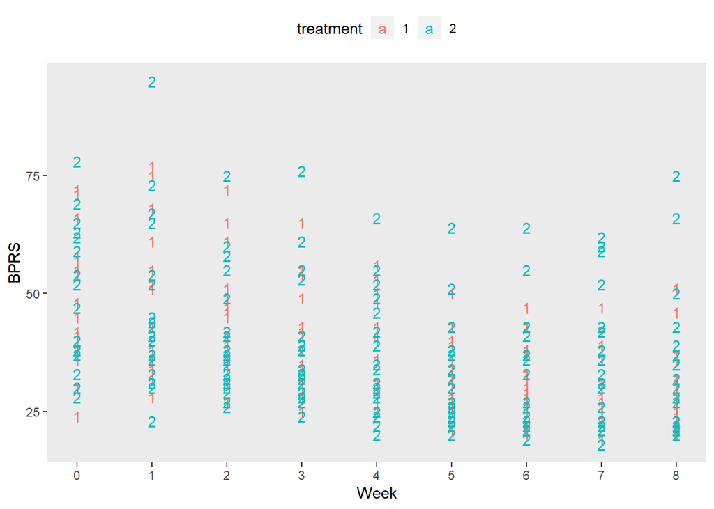

```r
# Draw the plot
ggplot(BPRSL, aes(x = week, y = bprs, group = subject, color = treatment)) + geom_text(aes(label = treatment)) + scale_x_continuous(name = "Week", breaks = seq(0, 8, 1)) +scale_y_continuous(name = "BPRS") + theme(legend.position = "top") + theme(panel.grid.major = element_blank(), panel.grid.minor = element_blank())
```

Based on the plot above, the bprs rate seems to descrease over time in the first group. In the second group, there is variation in the bprs rates over the time period.

## Linear Regression Model

The Linear Regression Model will be fitted to BPRS data, bprs as the target variable and week and treatment as the explanatory variables. We ignore the repeated-measures structure of the data.

```r
BPRS_reg <- lm(bprs ~ week + treatment, data = BPRSL)
summary(BPRS_reg)
```

```
##
## Call:
## lm(formula = bprs ~ week + treatment, data = BPRSL)
##
## Residuals:
##     Min      1Q  Median      3Q     Max
## -22.454  -8.965  -3.196   7.002  50.244
##
## Coefficients:
##             Estimate Std. Error t value Pr(>|t|)
## (Intercept)  46.4539     1.3670  33.982   <2e-16 ***
## week         -2.2704     0.2524  -8.995   <2e-16 ***
## treatment2    0.5722     1.3034   0.439    0.661
## ---
## Signif. codes:  0 '***' 0.001 '**' 0.01 '*' 0.05 '.' 0.1 ' ' 1
##
## Residual standard error: 12.37 on 357 degrees of freedom
## Multiple R-squared:  0.1851, Adjusted R-squared:  0.1806
## F-statistic: 40.55 on 2 and 357 DF,  p-value: < 2.2e-16
```

The statistical analysis indicate that variable treatment is not statistically significant variable and doesn’t have impact on the model.

We plot the individual response profiles of BPRS data.

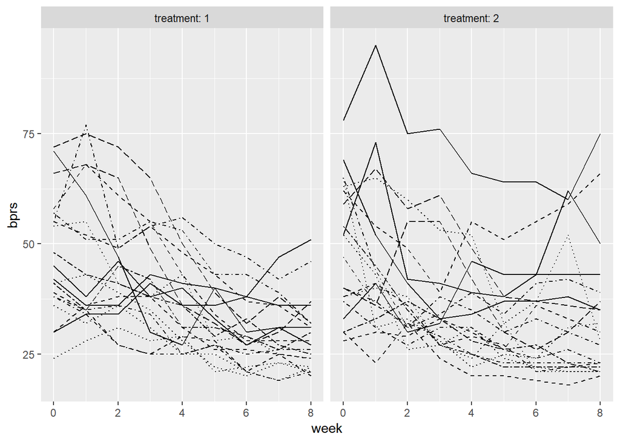

```r
# Draw the plot
ggplot(BPRSL, aes(x = week, y = bprs, linetype = subject)) +
  geom_line() +
  scale_linetype_manual(values = rep(1:10, times=4)) +
  facet_grid(. ~ treatment, labeller = label_both) +
  theme(legend.position = "none") +
  scale_y_continuous(limits = c(min(BPRSL$bprs), max(BPRSL$bprs)))
```

The graphics above showcases that the BPRS score of almost all the men is decreasing over the eight weeks of the study. The men who have higher BPRS values at the beginning tend to have higher values throughout the study. The graphics shows that there are big individual differences and variability appears to decrease with time.